# FLO replication - analysis + results summary

Eva

6/15/2020

This script works by loading the pre-processed files.

# clean WS, set WD

```r
rm(list = ls());
```

Set your local working directory. This should be (and is assumed to be in the rest of the code) the highest point in your local folder:

```r
localGitDir <- 'C:/Users/eva_v/Documents/GitHub/leverhulmeNDL'
```

# Load functions from the lab repo

```r
urlFolder <- 'https://api.github.com/repos/n400peanuts/languagelearninglab/git/trees/master?recursive=1'
urlRaw <- 'https://raw.githubusercontent.com/n400peanuts/languagelearninglab/master/tools/'

loadFunctionsGithub <-function(urlFolder, urlRaw){
  if (!require(httr)) {
    stop("httr not installed")
  }
  else if (!require(RCurl)){
    stop("RCurl not installed")
  }
  else {
    print('----loading. Please wait----')
  };
  httr::GET(urlFolder)-> req
  stop_for_status(req)
  filelist <- unlist(lapply(content(req)$tree, "[", "path"), use.names = F)
  urlFunctions <- grep("docs/tools/", filelist, value = TRUE, fixed = TRUE)
  gsub("docs/tools/", "", urlFunctions) -> functions
  for (i in 1:length(functions)){
    RCurl::getURL(paste0(urlRaw, functions[i]), ssl.verifypeer = FALSE)-> temp
    eval(parse(text = temp), envir = .GlobalEnv)
  };
}

loadFunctionsGithub(urlFolder = urlFolder, urlRaw = urlRaw);
```

```
## [1] "----loading. Please wait----"
```

```r
rm(urlFolder, urlRaw, loadFunctionsGithub)
```

# load preprocessed files

```r
generalizationPL <-read.table(paste(localGitDir, "/exp1/data/generalizationPL.txt", sep = ""), header = T, stringsAsFactors = T)

generalizationLP <-read.table(paste(localGitDir, "/exp1/data/generalizationLP.txt", sep = ""), header = T, stringsAsFactors = T)

contingencyJudgement <-read.table(paste(localGitDir, "/exp1/data/contingencyJudgment.txt", sep = ""), header = T, stringsAsFactors = T)

randomDot <-read.table(paste(localGitDir, "/exp1/data/randomDot.txt", sep = ""), header = T, stringsAsFactors = T)

learning <-read.table(paste(localGitDir, "/exp1/data/learning.txt", sep = ""), header = T, stringsAsFactors = T)
```

# Data visualization

1. Learning and Testing was presented as it was supposed to be and
2. data was stored correctly

Let’s see now if data makes sense.

## Reaction times

```r
rbind(generalizationPL, generalizationLP, contingencyJudgement)-> alltasks
alltasks <- droplevels(alltasks)
```

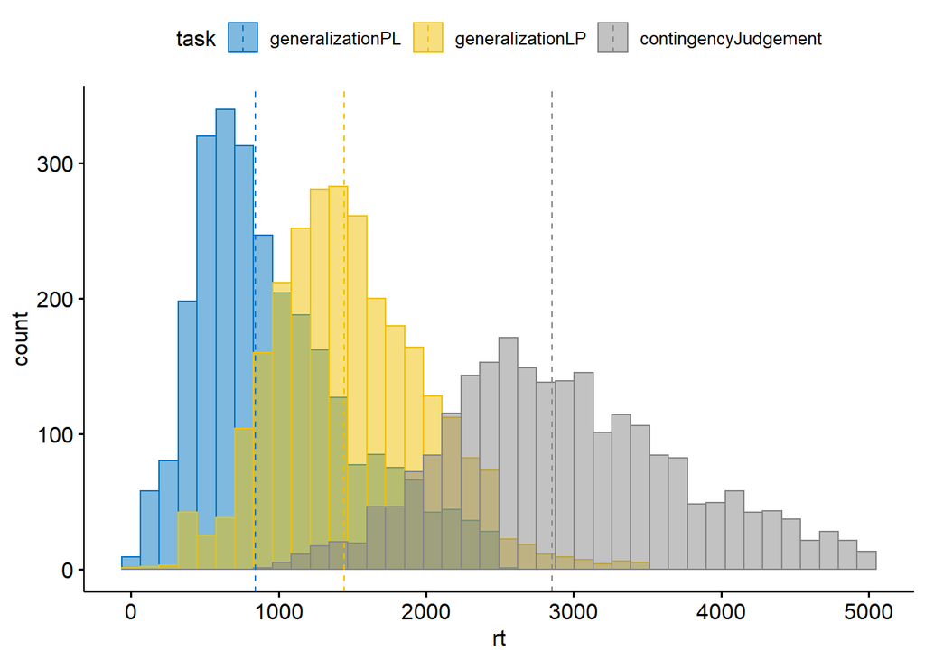

```r
gghistogram(alltasks,
       x = "rt",
       y = "..count..",
       xlab = "rt",
       color = "task",
       fill = "task",
       bins = 40,
       palette = "jco",
       add = "median"
)
```

The two generalization tasks looks quite different. I’m going to plot it separately for a better inspection:

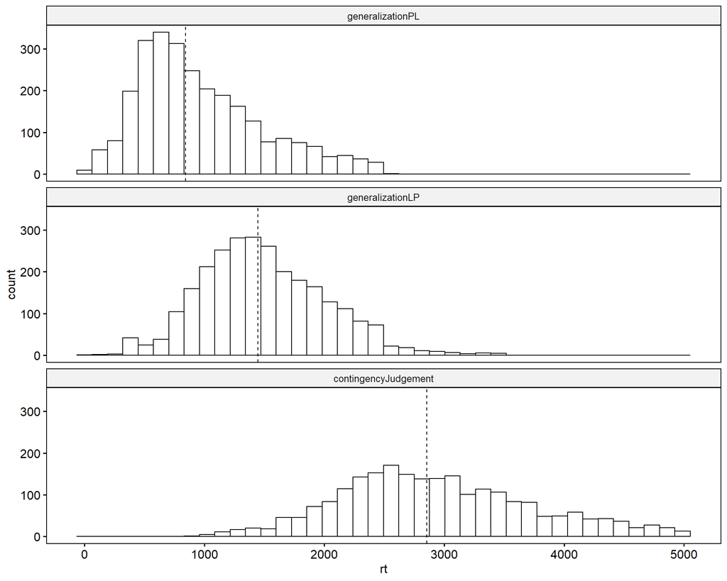

```r
p<- gghistogram(alltasks, #will throw warnings related to non responses but that's okay, ggplot simply removes them
       x = "rt",
       y = "..count..",
       xlab = "rt",
       facet.by = "task",
       add = "median",
       bins = 40
)

facet(p, facet.by = "task",
      nrow = 3,
      ncol = 1)
```

The tails of the first two tasks don’t end smoothly, especially in task 2.

## accuracy

### RandomDot

```r
unique(randomDot$subjID)-> subj;
randomDot-> randomTask

trials <- c(rep('0', 6), rep('1', 5),
              rep('2', 5), rep('3', 5),
              rep('4', 5))

trialstot <- as.factor(rep(trials, length(subj)))

randomTask$blocks <- trialstot
```

#### How many timeouts by participant?

```r
randomTask$timeout <- ifelse(randomTask$resp== -1, 1, 0)
```

```r
temp<-randomTask %>%
  count(timeout, subjID) %>%
  filter(timeout == 1)

unique(temp$subjID)-> subjs

temp2<-randomTask[!(randomTask$subjID %in% subjs),] %>%
  count(timeout, subjID,  ) %>%
  filter(timeout == 0)

temp2[temp2$timeout==0,]$n <- 0

rbind(temp,temp2)-> timeout
```

Histrogram by participant:

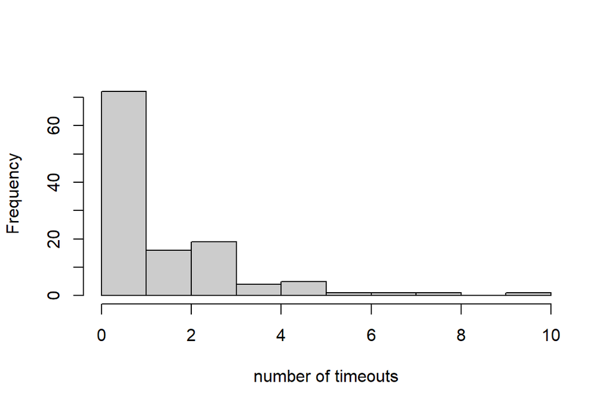

```r
hist(timeout$n, xlab = 'number of timeouts',
     main = '',
     col=grey(.80),
     border=grey(0),
     breaks = seq(0,max(timeout$n),1))
```

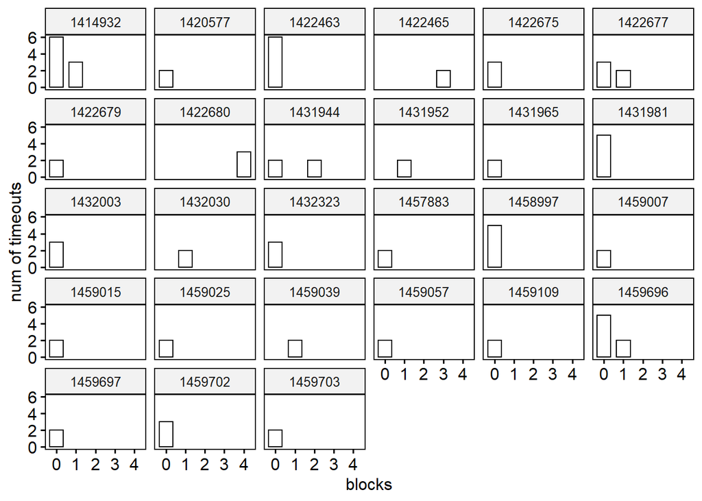

```r
timeout <- randomTask %>%
  group_by(subjID, blocks) %>%
  filter(resp == -1) %>%
  count()


ggbarplot(timeout[timeout$n>1 ,], x = "blocks", y = "n",
          facet.by = "subjID",
          sort.by.groups = TRUE,     # Sort inside each group
          ylab = "num of timeouts")
```

#### Subjects that made more than 3 timeouts

```r
unique(timeout[timeout$n>3,]$subjID) -> problematicPeople
```

```r
accdistr <- randomTask[!(randomTask$resp == -1),] %>%
  group_by(subjID, blocks,  ) %>%
  summarise(m = mean(acc))
```

```r
accdistr <- randomTask[!(randomTask$resp == -1),] %>%
  group_by(subjID, blocks) %>%
  summarise(m = mean(acc))
```

#### People that scored less than 70%:

```r
unique(accdistr[accdistr$m<.7,]$subjID) -> dumbPeople
```

```r
setdiff(dumbPeople, problematicPeople)-> dumbPeople
```

Let’s consider them as bad subjects.

```r
c(problematicPeople, dumbPeople)->badsubjs
```

```r
rm(temp, temp2, timeout, subj, subjs, trials, trialstot, accdistr, problematicPeople, dumbPeople,p)
```

### Task 1: from picture to labels

The column fribbleID stores the fribble presented, while the column label stores the labels presented. Resp column in this task refers to the label selected. Category and frequency refers to the fribbleID column.

I’m going to add 1 in the accuracy column for every instance where response matches the category column, i.e., the participant correctly associated the fribble to its label.

I remove the no-response, and compute accuracy based on category and response.

#### How many participants do we have per learning?

```r
length(unique(generalizationPL$subjID))
```

```
## [1] 120
```

```r
fl<- length(unique(generalizationPL[generalizationPL$learning=='FL' &
                                      !(generalizationPL$subjID %in% badsubjs),]$subjID))
lf<- length(unique(generalizationPL[generalizationPL$learning=='LF' &
                                      !(generalizationPL$subjID %in% badsubjs),]$subjID))
fl
```

```
## [1] 55
```

```r
lf
```

```
## [1] 47
```

We have 55 for feature-label learning, and 47 for label-feature learning.

#### Check tails of the rt distribution

The point is that we can’t rely on responses made very early, because these might be simply mistakes or technical errors.

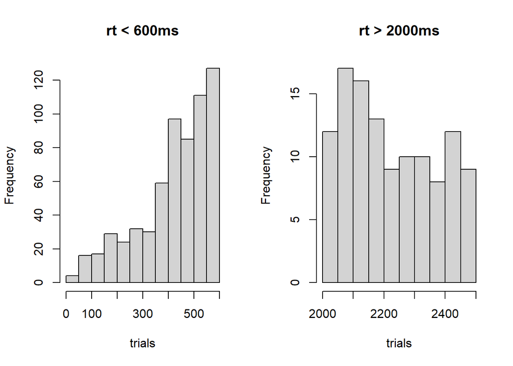

```r
par(mfrow=c(1,2))
hist(generalizationPL[generalizationPL$rt<600 &
                        !(generalizationPL$subjID %in% badsubjs),]$rt, main = 'rt < 600ms', xlab = 'trials');

hist(generalizationPL[generalizationPL$rt>2000 &
                        !(generalizationPL$subjID %in% badsubjs),]$rt, main = 'rt > 2000ms', xlab = 'trials');
```

```r
par(mfrow=c(1,1))
```

I would remove rt <100ms for all tasks.

#### How many, what type of trials do we have?

```r
round(nrow(generalizationPL[generalizationPL$rt<100 &
                              !(generalizationPL$subjID %in% badsubjs),]) / nrow(generalizationPL[!(generalizationPL$subjID %in% badsubjs),])*100,2)
```

```
## [1] 6.74
```

```r
rm(fl,lf)
pictureLabel <- generalizationPL[!(is.na(generalizationPL$resp)),]

pictureLabel$acc <- 0;
pictureLabel[pictureLabel$category==1 & pictureLabel$resp=='dep',]$acc <- 1;

pictureLabel[pictureLabel$category==2 & pictureLabel$resp=='bim',]$acc <- 1;

pictureLabel[pictureLabel$category==3 & pictureLabel$resp=='tob',]$acc <- 1;
```

```r
n <- length(unique(pictureLabel[!(pictureLabel$subjID %in% badsubjs),]$subjID))

nrows <- (nrow(generalizationPL[!(generalizationPL$subjID %in% badsubjs),])) - (nrow(pictureLabel[!(pictureLabel$subjID %in% badsubjs),]))
```

```r
sort(unique(pictureLabel[!(pictureLabel$subjID %in% badsubjs),]$subjID))-> subjs;
sort(unique(generalizationPL[!(generalizationPL$subjID %in% badsubjs),]$subjID)) ->totsubjs;

subjmissed<- setdiff(totsubjs, subjs);

rm(subjs, totsubjs);
```

We have 101 participants in this task, this is -1 compared to our total number of participants. The subject(s) that didn’t answer at all the task is: 1420171. We have lost also 145 responses, that is 5.0347222 over the total: 2880.

How many trials per participant do we have now?

```r
pictureLabel %>%
  group_by(subjID) %>%
  count() %>% filter(n<=18)
```

```
## # A tibble: 2 x 2
## # Groups:   subjID [2]
##    subjID     n
##     <int> <int>
## 1 1422475    18
## 2 1432075    18
```

No one had less than 18 trials, over the total (24). That’s fine!

#### Barplot accuracy by category + frequency + learning

picture label

```r
c(badsubjs, subjmissed) -> badsubjs

rm(n, subjmissed, nrows)

ss_prop<-aggregate(acc ~ frequency+category+subjID+learning,
                   data = pictureLabel[pictureLabel$rt > 100 &
                                       !(pictureLabel$subjID %in% badsubjs),], FUN = mean)
```

Plot aggregated over subjs. To see accuracy distributed over categories.

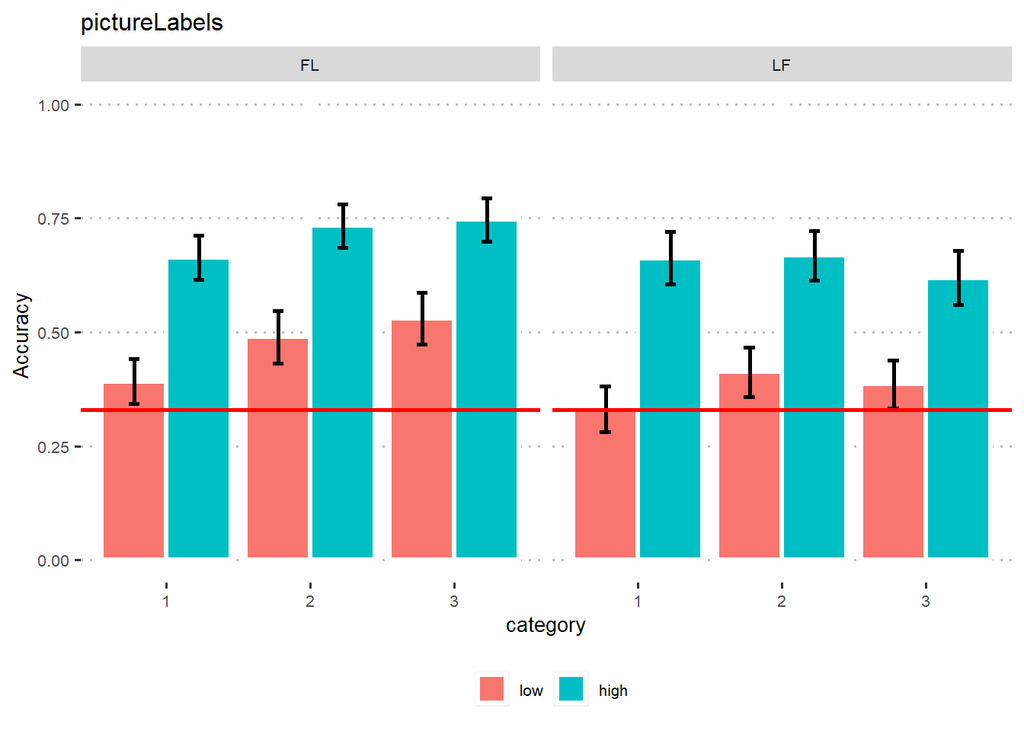

```r
ms <- ss_prop %>%
  group_by( category, frequency, learning) %>%
  summarise(n=n(),
    mean=mean(acc),
    sd=sd(acc)
  ) %>%
  mutate( se=sd/sqrt(n))  %>%
  mutate( ci=se * qt((1-0.05)/2 + .5, n-1))

ms$frequency <- as.factor(ms$frequency)
plyr::revalue(ms$frequency, c("25"="low"))-> ms$frequency;
plyr::revalue(ms$frequency, c("75"="high"))-> ms$frequency;

ggplot(aes(x = category, y = mean, fill = frequency), data = ms) +
  facet_grid( . ~ learning) +
  geom_bar(stat = "identity", color='white', position=position_dodge(), size=1.2) +
  geom_errorbar(aes(ymin=mean-se, ymax=mean+se), width=.15, size=1,position=position_dodge(.9)) +
  ylab("Accuracy ") +
  xlab("category") +
  ggtitle('pictureLabels') +
  coord_cartesian(ylim = c(0, 1))+
  ggpubr::theme_pubclean() +
  theme(legend.position="bottom", legend.title = element_blank()) +
  theme(text = element_text(size=10)) +
  geom_hline(yintercept = .33, col='red', lwd=1);
```

#### Violin plot accuracy by category + frequency + learning

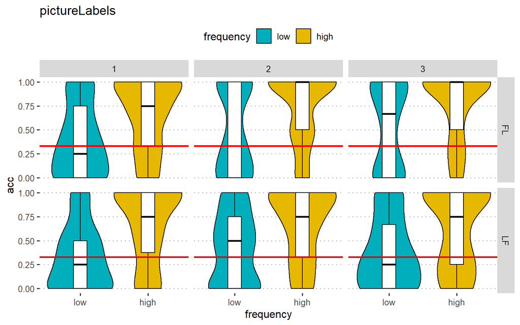

```r
df <- aggregate(acc ~ subjID+frequency+learning+category,
                data = pictureLabel[pictureLabel$rt > 100  &
                                       !(pictureLabel$subjID %in% badsubjs),], mean)
df$frequency <- as.factor(df$frequency)
plyr::revalue(df$frequency, c("25"="low"))-> df$frequency;
plyr::revalue(df$frequency, c("75"="high"))-> df$frequency;

ggviolin(df, x = "frequency", y = "acc", fill = "frequency",
         palette = c("#00AFBB", "#E7B800"),
         add = "boxplot",
         add.params = list(fill = "white"),
         trim=TRUE) +
        ggtitle('pictureLabels') +
        facet_grid( learning ~ category) +
        theme_pubclean()+
  geom_hline(yintercept = .33, col='red', lwd=1);
```

#### Violin plot accuracy by frequency + learning

Let’s see how participants scored for the high/low frequency:

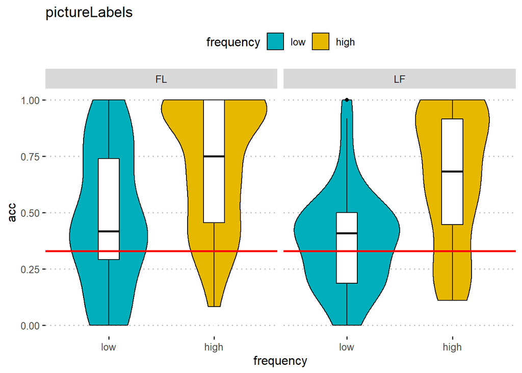

```r
df <- aggregate(acc ~ subjID+frequency+learning,
                data = pictureLabel[pictureLabel$rt > 100  &
                                       !(pictureLabel$subjID %in% badsubjs),], mean)
df$frequency <- as.factor(df$frequency)
plyr::revalue(df$frequency, c("25"="low"))-> df$frequency;
plyr::revalue(df$frequency, c("75"="high"))-> df$frequency;

ggviolin(df, x = "frequency", y = "acc", fill = "frequency",
         palette = c("#00AFBB", "#E7B800"),
         add = "boxplot",
         add.params = list(fill = "white"),
         trim=TRUE) +
        ggtitle('pictureLabels') +
        facet_grid( . ~ learning) +
        theme_pubclean()+
  geom_hline(yintercept = .33, col='red', lwd=1);
```

```r
df %>%
  group_by(learning, frequency) %>%
  summarise(mean(acc))
```

```
## # A tibble: 4 x 3
## # Groups:   learning [2]
##   learning frequency `mean(acc)`
##   <fct>    <fct>           <dbl>
## 1 FL       low             0.474
## 2 FL       high            0.721
## 3 LF       low             0.376
## 4 LF       high            0.656
```

Closer inspection:

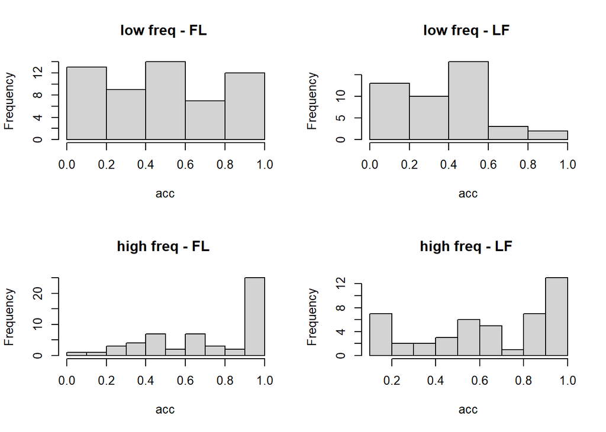

```r
par(mfrow=c(2,2))
hist(df[df$frequency=='low' & df$learning=='FL' ,]$acc, xlab = 'acc', main = 'low freq - FL ')
hist(df[df$frequency=='low' & df$learning=='LF',]$acc, xlab = 'acc', main = 'low freq - LF ')
hist(df[df$frequency=='high' & df$learning=='FL',]$acc, xlab = 'acc', main = 'high freq - FL ')
hist(df[df$frequency=='high' & df$learning=='LF',]$acc, xlab = 'acc', main = 'high freq - LF ')
```

```r
par(mfrow=c(1,1))
```

#### Barplot accuracy by frequency + learning

```r
#barPlot aggregated over categories:

ms <- aggregate(acc ~ subjID+frequency+learning,
                data=pictureLabel[pictureLabel$rt > 100 &
                                  !(pictureLabel$subjID %in% badsubjs)  ,], FUN= mean)

df<- ms %>%
  group_by(frequency, learning)%>%
  summarise(
    mean = mean(acc),
    sd = sd(acc),
    n = n()) %>%
  mutate( se=sd/sqrt(n))  %>%
  mutate( ci=se * qt((1-0.05)/2 + .5, n-1))

df$frequency <- as.factor(df$frequency)
plyr::revalue(df$frequency, c("25"="low"))-> df$frequency;
plyr::revalue(df$frequency, c("75"="high"))-> df$frequency;


pl<-ggplot(aes(x = frequency, y = mean, fill = frequency), data = df) +
  facet_grid( . ~ learning) +
  geom_bar(stat = "identity", color='white', position=position_dodge(), size=1.2) +
  geom_errorbar(aes(ymin=mean-se, ymax=mean+se), width=.15, size=1,position=position_dodge(.9)) +
  ylab("Accuracy ") +
  xlab("frequency") +
  ggtitle('pictureLabels') +
  coord_cartesian(ylim = c(0, 1))+
  ggpubr::theme_pubclean() +
  theme(legend.position = "none") +
  theme(text = element_text(size=10)) +
  geom_hline(yintercept = .33, col='red', lwd=1);
```

```r
rbind(lowFreqFL, highFreqFL, lowFreqLF, highFreqLF)-> pictureLabel_respType
rm(lowFreqFL, highFreqFL, lowFreqLF, highFreqLF)
```

### save file

```r
write.table(pictureLabel, paste(localGitDir, "/exp1/data/pictureLabel.txt", sep = ""), col.names = T, row.names = F, quote = F)
```

### Task 2: from label to pictures

Let’s check now the generalizaton from label to pictures:

```r
length(unique(generalizationLP$subjID))
```

```
## [1] 120
```

```r
fl<- length(unique(generalizationLP[generalizationLP$learning=='FL' &
                                      !(generalizationLP$subjID %in% badsubjs),]$subjID))

lf<- length(unique(generalizationLP[generalizationLP$learning=='LF' &
                                      !(generalizationLP$subjID %in% badsubjs),]$subjID))
fl
```

```
## [1] 55
```

```r
lf
```

```
## [1] 46
```

#### How many participants do we have per learning?

We have 55 for feature-label learning, and 46 for label-feature learning.

```r
rm(fl,lf)
labelPicture <- generalizationLP[!(is.na(generalizationLP$resp)),]
n<- length(unique(labelPicture$subjID))
nrows <- (nrow(generalizationLP)) - (nrow(labelPicture))

sort(unique(labelPicture$subjID))-> subjs;
sort(unique(generalizationLP$subjID)) ->totsubjs;

subjmissed<- setdiff(totsubjs, subjs);
```

Great, we have 120 participants in this task, so -0, and we have missed 195 over the total 2880, that is 6.7708333. The subject(s) that missed completely the task is: .

#### How many, what type of trials do we have?

How many datapoints did we lose for no-responses?

```r
round(nrow(generalizationLP[(is.na(generalizationLP$resp)) &
                              !(generalizationLP$subjID %in% badsubjs),]) /nrow(generalizationLP[!(generalizationLP$subjID %in% badsubjs),])*100,2)
```

```
## [1] 6.77
```

How many trials were rt < 100?

```r
round(nrow(generalizationLP[generalizationLP$rt<100 &
                              !(generalizationLP$subjID %in% badsubjs),])/ nrow(generalizationLP[!(generalizationLP$subjID %in% badsubjs),])*100,2)
```

```
## [1] 6.81
```

Once trimmed, how many trials per participant do we have in this task?

```r
labelPicture %>%
  group_by(subjID) %>%
  count() %>%
  filter(n<=18)
```

```
## # A tibble: 8 x 2
## # Groups:   subjID [8]
##    subjID     n
##     <int> <int>
## 1 1420577    18
## 2 1422475    18
## 3 1422477    17
## 4 1422677    17
## 5 1422680     9
## 6 1422689    17
## 7 1432009     8
## 8 1432075    17
```

Here we have less datapoints. For sure, 1422680 needs to be added to the black list because has few correct trials.

```r
c(badsubjs, 1422680, 1432009) -> badsubjs
```

#### Check tails of the rt distribution

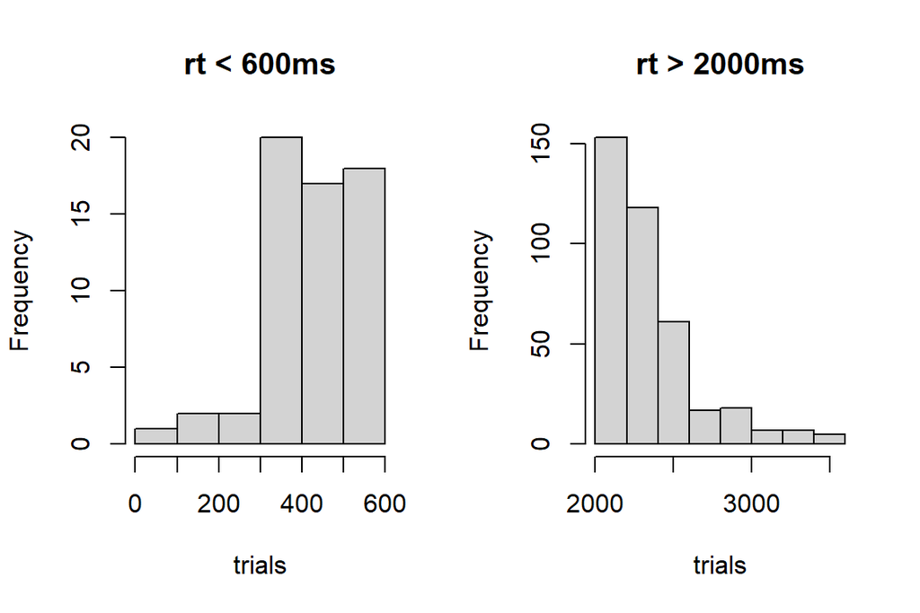

```r
par(mfrow=c(1,2))
hist(generalizationLP[generalizationLP$rt<600 &
                        !(generalizationLP$subjID %in% badsubjs),]$rt, main = 'rt < 600ms', xlab = 'trials');
hist(generalizationLP[generalizationLP$rt>2000 &
                        !(generalizationLP$subjID %in% badsubjs),]$rt, main = 'rt > 2000ms', xlab = 'trials');
```

```r
par(mfrow=c(1,1))
```

```r
rm(n, nrows, subjs, totsubjs);
labelPicture$acc <- 0;
labelPicture[labelPicture$category==1 & labelPicture$label=='dep',]$acc <- 1;
labelPicture[labelPicture$category==2 & labelPicture$label=='bim',]$acc <- 1;
labelPicture[labelPicture$category==3 & labelPicture$label=='tob',]$acc <- 1;
```

#### Barplot accuracy by category+learning+frequency

Calculate the proportion of correct in each condition

```r
rm(subjmissed)
ss_prop<-aggregate(acc ~ frequency+category+subjID+learning,
                   data = labelPicture[labelPicture$rt > 100 &
                                         labelPicture$rt <= 2500 &
                                         !(labelPicture$subjID %in% badsubjs),], FUN = mean)
```

Plot aggregated over subjs. To see accuracy distributed over categories.

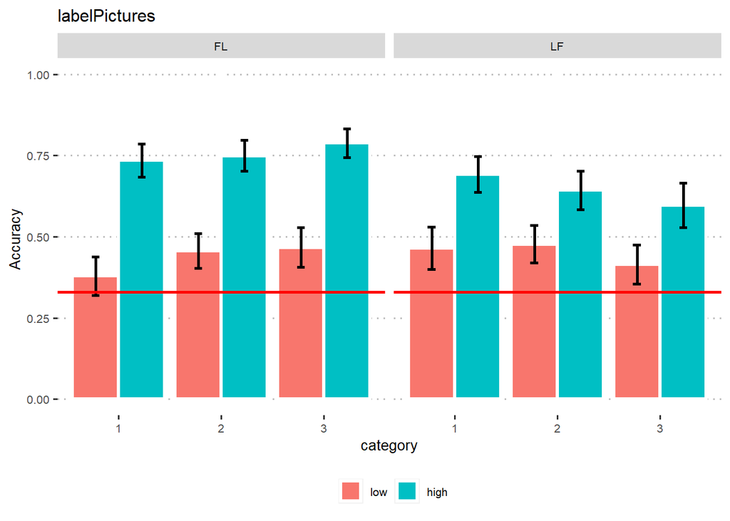

```r
ms <- ss_prop %>%
  group_by(category, frequency, learning) %>%
  summarise(
    n=n(),
    mean=mean(acc),
    sd=sd(acc)
  ) %>%
  mutate( se=sd/sqrt(n))  %>%
  mutate( ci=se * qt((1-0.05)/2 + .5, n-1))

ms$frequency <- as.factor(ms$frequency)
plyr::revalue(ms$frequency, c("25"="low"))-> ms$frequency;
plyr::revalue(ms$frequency, c("75"="high"))-> ms$frequency;

ggplot(aes(x = category, y = mean, fill = frequency), data = ms) +
  facet_grid( . ~ learning) +
  geom_bar(stat = "identity", color='white', position=position_dodge(), size=1.2) +
  geom_errorbar(aes(ymin=mean-se, ymax=mean+se), width=.15, size=1,position=position_dodge(.9)) +
  ylab("Accuracy ") +
  xlab("category") +
  ggtitle('labelPictures') +
  coord_cartesian(ylim = c(0, 1))+
  ggpubr::theme_pubclean() +
  theme(legend.position="bottom", legend.title = element_blank()) +
  theme(text = element_text(size=10)) +
  geom_hline(yintercept = .33, col='red', lwd=1);
```

#### Violin plot accuracy by category+learning+frequency

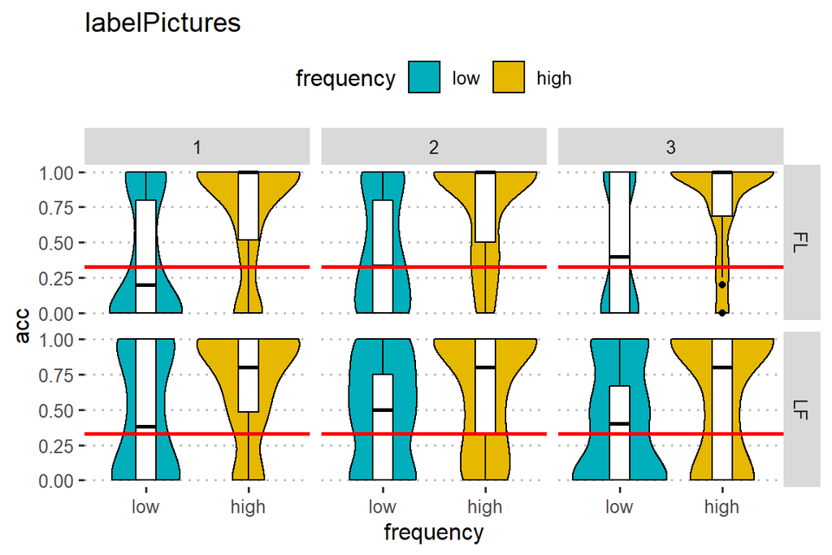

```r
ms <- aggregate(acc ~ subjID+frequency+learning+category,
                data = labelPicture[labelPicture$rt > 100 &
                                      labelPicture$rt <=2500 &
                                         !(labelPicture$subjID %in% badsubjs),], mean)

ms$frequency <- as.factor(ms$frequency)
plyr::revalue(ms$frequency, c("25"="low"))-> ms$frequency;
plyr::revalue(ms$frequency, c("75"="high"))-> ms$frequency;

ggviolin(ms, x = "frequency", y = "acc", fill = "frequency",
         palette = c("#00AFBB", "#E7B800"),
         add = "boxplot",
         add.params = list(fill = "white"),
         trim=TRUE) +
         ggtitle('labelPictures') +
        facet_grid( learning ~ category) +
        theme_pubclean()+
  geom_hline(yintercept = .33, col='red', lwd=1);
```

```r
#rm(ms, ss_prop)
```

#### Violinplot accuracy by learning+frequency

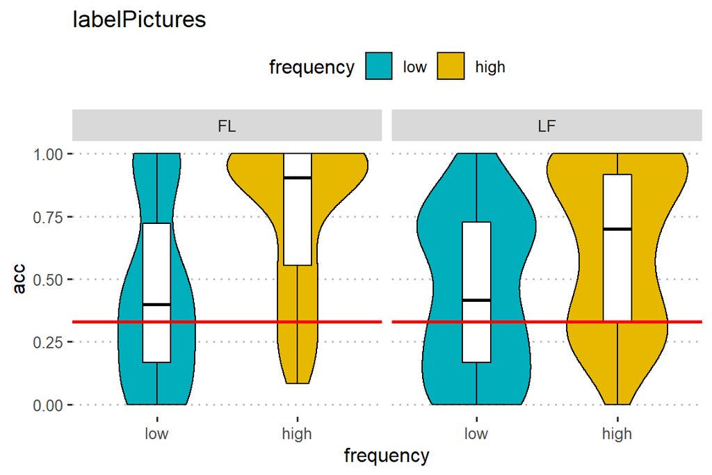

```r
ms <- aggregate(acc ~ subjID+frequency+learning,
                data = labelPicture[labelPicture$rt > 100 &
                                      labelPicture$rt <= 2500 &
                                         !(labelPicture$subjID %in% badsubjs),], mean)

ms$frequency <- as.factor(ms$frequency)
plyr::revalue(ms$frequency, c("25"="low"))-> ms$frequency;
plyr::revalue(ms$frequency, c("75"="high"))-> ms$frequency;

ggviolin(ms, x = "frequency", y = "acc", fill = "frequency",
         palette = c("#00AFBB", "#E7B800"),
         add = "boxplot",
         add.params = list(fill = "white"),
         trim=TRUE) +
         ggtitle('labelPictures') +
        facet_grid( . ~ learning) +
        theme_pubclean()+
  geom_hline(yintercept = .33, col='red', lwd=1);
```

```r
#rm(ms, ss_prop)
```

```r
ms %>%
  group_by(learning, frequency) %>%
  summarise(mean(acc))
```

```
## # A tibble: 4 x 3
## # Groups:   learning [2]
##   learning frequency `mean(acc)`
##   <fct>    <fct>           <dbl>
## 1 FL       low             0.439
## 2 FL       high            0.750
## 3 LF       low             0.439
## 4 LF       high            0.644
```

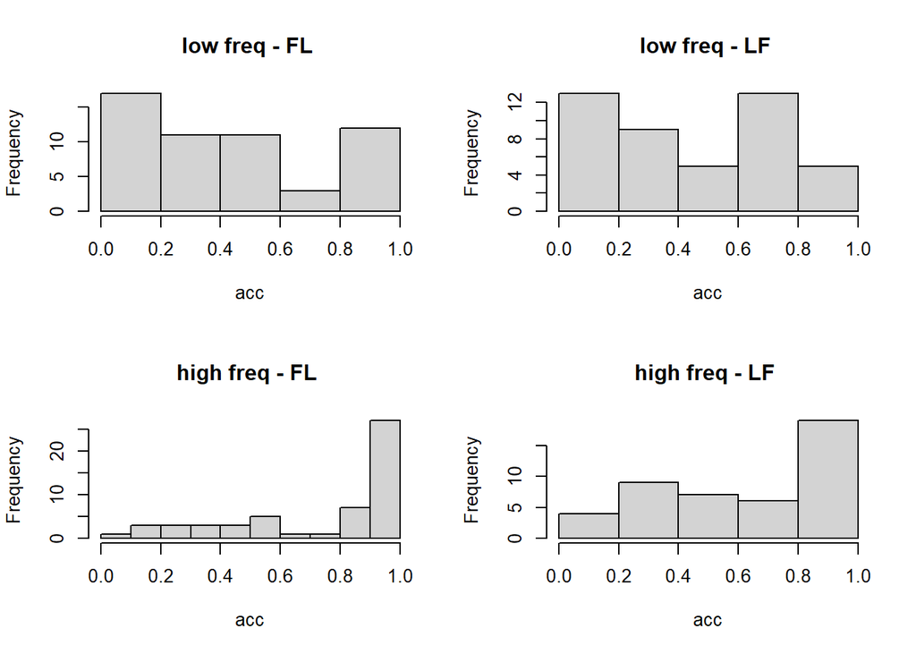

```r
par(mfrow=c(2,2))
hist(ms[ms$frequency=='low' & ms$learning=='FL',]$acc, xlab = 'acc', main = 'low freq - FL ')
hist(ms[ms$frequency=='low' & ms$learning=='LF',]$acc, xlab = 'acc', main = 'low freq - LF ')
hist(ms[ms$frequency=='high' & ms$learning=='FL',]$acc, xlab = 'acc', main = 'high freq - FL ')
hist(ms[ms$frequency=='high' & ms$learning=='LF',]$acc, xlab = 'acc', main = 'high freq - LF ')
```

```r
par(mfrow=c(1,1))
```

#### Barplot accuracy by frequency + learning

```r
#barPlot aggregated over categories:

ms <- aggregate(acc ~ subjID+frequency+learning,
                data=labelPicture[labelPicture$rt > 100 &
                                    labelPicture$rt <= 2500 &
                                  !(labelPicture$subjID %in% badsubjs)  ,], FUN= mean)

df<- ms %>%
  group_by(frequency, learning)%>%
  summarise(
    mean = mean(acc),
    sd = sd(acc),
    n = n()) %>%
  mutate( se=sd/sqrt(n))  %>%
  mutate( ci=se * qt((1-0.05)/2 + .5, n-1))

df$frequency <- as.factor(df$frequency)
plyr::revalue(df$frequency, c("25"="low"))-> df$frequency;
plyr::revalue(df$frequency, c("75"="high"))-> df$frequency;


lp<-ggplot(aes(x = frequency, y = mean, fill = frequency), data = df) +
  facet_grid( . ~ learning) +
  geom_bar(stat = "identity", color='white', position=position_dodge(), size=1.2) +
  geom_errorbar(aes(ymin=mean-se, ymax=mean+se), width=.15, size=1,position=position_dodge(.9)) +
  ylab("Accuracy ") +
  xlab("frequency") +
  ggtitle('labelPictures') +
  coord_cartesian(ylim = c(0, 1))+
  ggpubr::theme_pubclean() +
  theme(legend.position="bottom", legend.title = element_blank()) +
  theme(text = element_text(size=10)) +
  geom_hline(yintercept = .33, col='red', lwd=1);
```

```r
rbind(lowFreqFL, highFreqFL, lowFreqLF, highFreqLF)-> labelPicture_respType
rm(lowFreqFL, highFreqFL, lowFreqLF, highFreqLF)
```

### Comparison by frequency by learning by tasks

Quick summary of what we have so far:

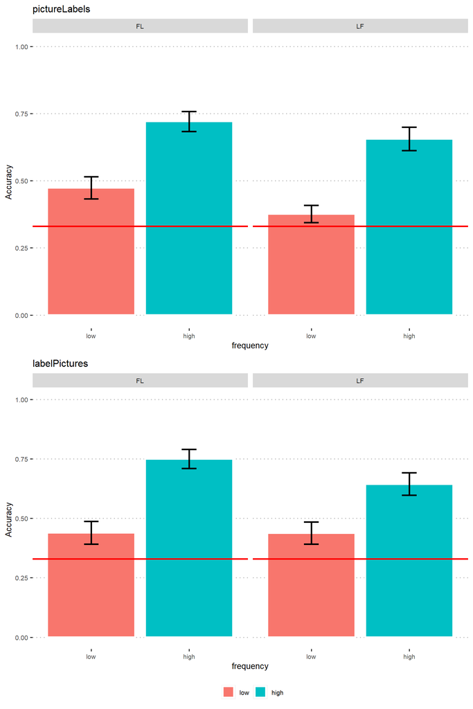

```r
grid.arrange(pl,lp)
```

What’s going on in the low frequency condition? One way to see whether they simply learned another association is to check that wrong choices are distributed equally (50%) to the other two categories. If they are, then they didn’t learn anything, but if they are not distributed equally, they have learned another association.

Label picture:

```r
#select only inaccurate trials
temp <- labelPicture[labelPicture$acc==0,]

round(nrow(temp)/nrow(labelPicture)*100,2)
```

```
## [1] 46.07
```

How many of those are low frequency trials?

```r
round(nrow(temp[temp$frequency==25,])/nrow(labelPicture)*100,2)
```

```
## [1] 29.5
```

How many of those are low frequency trials and how are they distributed across learnings?

```r
round(nrow(temp[temp$frequency==25 & temp$learning=="FL",])/nrow(labelPicture)*100,2)
```

```
## [1] 15.79
```

```r
round(nrow(temp[temp$frequency==25 & temp$learning=="LF",])/nrow(labelPicture)*100,2)
```

```
## [1] 13.71
```

FL people make more errors in the low freq condition

How many of those are high frequency trials and how are they distributed across learnings?

```r
round(nrow(temp[temp$frequency==75 & temp$learning=="FL",])/nrow(labelPicture)*100,2)
```

```
## [1] 7.19
```

```r
round(nrow(temp[temp$frequency==75 & temp$learning=="LF",])/nrow(labelPicture)*100,2)
```

```
## [1] 9.39
```

While they are pretty much the same in the high frequency

Label picture task:

correct choice is listed in “label”, that is, label presented. Participant’s choice is listed in “category”, that is, the fribble’s category.

```r
temp %>%
  filter(frequency=="25") %>%
  group_by(learning, label, category) %>%
  count()
```

```
## # A tibble: 12 x 4
## # Groups:   learning, label, category [12]
##    learning label category     n
##    <fct>    <fct>    <int> <int>
##  1 FL       bim          1    36
##  2 FL       bim          3    92
##  3 FL       dep          2   107
##  4 FL       dep          3    43
##  5 FL       tob          1   107
##  6 FL       tob          2    39
##  7 LF       bim          1    22
##  8 LF       bim          3   100
##  9 LF       dep          2    74
## 10 LF       dep          3    44
## 11 LF       tob          1    78
## 12 LF       tob          2    50
```

Nope, they definitely learned another association. The association they have learned is based on the high saliency feature, rather than on the low saliency one. Let’s see if that is the case also for the other task:

Picture label task:

```r
#select only inaccurate trials
temp <- pictureLabel[pictureLabel$acc==0,]

round(nrow(temp)/nrow(pictureLabel)*100,2)
```

```
## [1] 46.26
```

How many of those are low frequency trials?

```r
round(nrow(temp[temp$frequency==25,])/nrow(pictureLabel)*100,2)
```

```
## [1] 29.93
```

How many of those are low frequency trials and how are they distributed across learnings?

```r
round(nrow(temp[temp$frequency==25 & temp$learning=="FL",])/nrow(pictureLabel)*100,2)
```

```
## [1] 15.44
```

```r
round(nrow(temp[temp$frequency==25 & temp$learning=="LF",])/nrow(pictureLabel)*100,2)
```

```
## [1] 14.48
```

How many of those are high frequency trials and how are they distributed across learnings?

```r
round(nrow(temp[temp$frequency==75 & temp$learning=="FL",])/nrow(pictureLabel)*100,2)
```

```
## [1] 7.93
```

```r
round(nrow(temp[temp$frequency==75 & temp$learning=="LF",])/nrow(pictureLabel)*100,2)
```

```
## [1] 8.41
```

Picture label task:

correct choice is listed in “category”, that is, the category of the fribble presented. Participant’s choice is listed in “resp” column, that is, the label chosen.

```r
temp %>%
  filter(frequency=="25") %>%
  group_by(learning, category, resp) %>%
  count()
```

```
## # A tibble: 12 x 4
## # Groups:   learning, category, resp [12]
##    learning category resp      n
##    <fct>       <int> <fct> <int>
##  1 FL              1 bim      44
##  2 FL              1 tob     110
##  3 FL              2 dep      78
##  4 FL              2 tob      60
##  5 FL              3 bim      83
##  6 FL              3 dep      42
##  7 LF              1 bim      53
##  8 LF              1 tob      93
##  9 LF              2 dep      61
## 10 LF              2 tob      55
## 11 LF              3 bim      91
## 12 LF              3 dep      38
```

In both tasks participants were driven by the high salient feature in making errors, they simply learned only one association between the label and the high salient feature, and made decisions based on this.

### save data

```r
write.table(labelPicture, paste(localGitDir, "/exp1/data/labelPicture.txt", sep = ""), col.names = T, row.names = F, quote = F)
```

## Speed-accuracy trade-off by tasks

Inspection of the speed-accuracy trade-off:

Label Picture

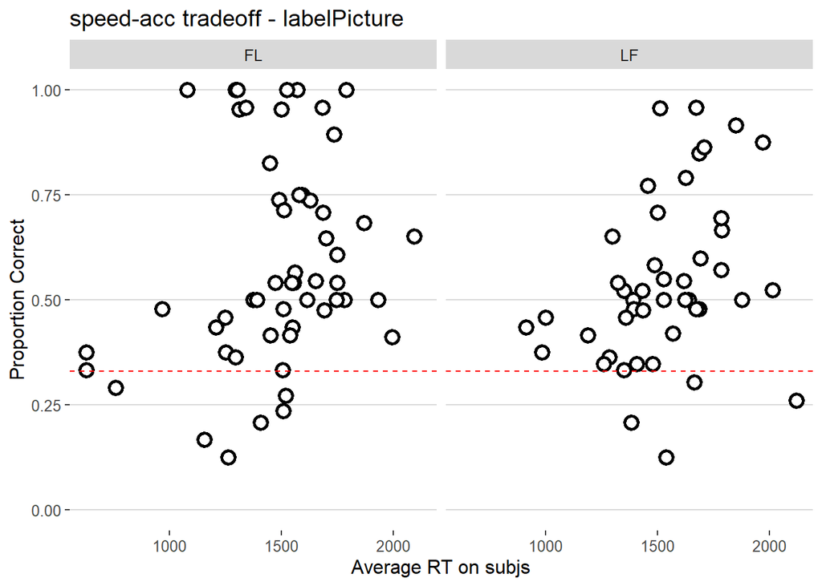

```r
aggregate(acc ~ subjID+learning, labelPicture[labelPicture$rt > 100 &
                                         !(labelPicture$subjID %in% badsubjs) ,], mean)-> speedacc

aggregate(rt ~ subjID+learning, labelPicture[labelPicture$rt > 100 &
                                         !(labelPicture$subjID %in% badsubjs),], mean)-> speedacc2
merge(speedacc, speedacc2, by =  c("subjID", "learning"))-> speedacc

ggplot(aes(x=rt, y=acc),
           data = speedacc) +
  facet_grid( . ~ learning) +
  geom_point( shape = 21, fill = "white", size = 3, stroke = 1.5) +
  #geom_smooth(method = "lm", formula = y ~ poly(x,2), se = TRUE, color = "#0892d0", fill = "lightgray") +
  geom_hline(yintercept = 0.33, lty = "dashed", color = 'red') +
  coord_cartesian(ylim = c(0, 1))+
  ggthemes::theme_hc()+
  xlab("Average RT on subjs") +
  ylab("Proportion Correct") +
  ggtitle("speed-acc tradeoff - labelPicture")
```

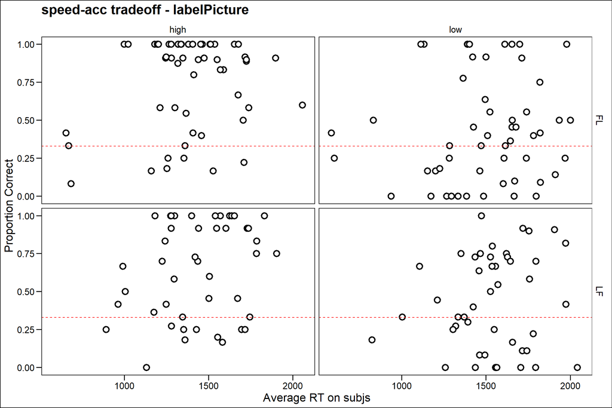

```r
aggregate(acc ~ subjID+learning+frequency, labelPicture[labelPicture$rt > 100 &
                                                          labelPicture$rt <= 2500 &
                                         !(labelPicture$subjID %in% badsubjs) ,], mean)-> speedacc

aggregate(rt ~ subjID+learning+frequency, labelPicture[labelPicture$rt > 100 &
                                                         labelPicture$rt <= 2500 &
                                         !(labelPicture$subjID %in% badsubjs),], mean)-> speedacc2
merge(speedacc, speedacc2, by =  c("subjID", "learning", "frequency"))-> speedacc
rm(speedacc2)
dplyr::recode(speedacc$frequency, "25"="low", "75"="high")-> speedacc$frequency;

ggplot(aes(x=rt, y=acc),
           data = speedacc) +
  facet_grid( learning ~ frequency) +
  geom_point( shape = 21, fill = "white", size = 3, stroke = 1.5) +
  #geom_smooth(method = "lm", formula = y ~ poly(x,2), se = TRUE, color = "#0892d0", fill = "lightgray") +
  geom_hline(yintercept = 0.33, lty = "dashed", color = 'red') +
  coord_cartesian(ylim = c(0, 1))+
  ggthemes::theme_base()+
  xlab("Average RT on subjs") +
  ylab("Proportion Correct") +
  ggtitle("speed-acc tradeoff - labelPicture")
```

```r
speedacc %>%
  group_by(frequency, learning) %>%
  summarise(mean(rt), median(rt))
```

```
## # A tibble: 4 x 4
## # Groups:   frequency [2]
##   frequency learning `mean(rt)` `median(rt)`
##   <chr>     <fct>         <dbl>        <dbl>
## 1 high      FL            1390.        1373.
## 2 high      LF            1441.        1435.
## 3 low       FL            1489.        1504.
## 4 low       LF            1539.        1537.
```

PictureLabel

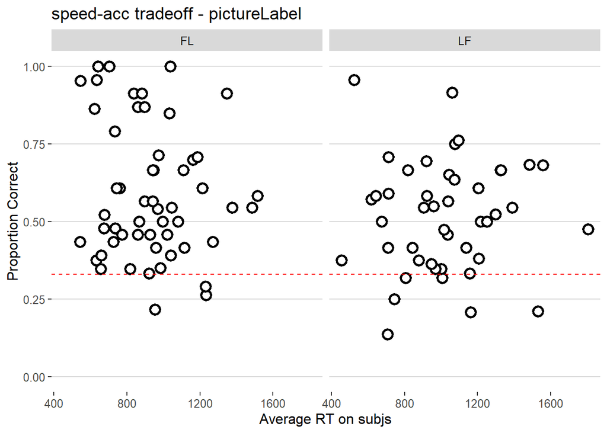

```r
aggregate(acc ~ subjID+learning, pictureLabel[pictureLabel$rt > 100  &
                                         !(pictureLabel$subjID %in% badsubjs),], mean)-> speedacc

aggregate(rt ~ subjID+learning, pictureLabel[pictureLabel$rt > 100  &
                                         !(pictureLabel$subjID %in% badsubjs),], mean)-> speedacc2
merge(speedacc, speedacc2, by =  c("subjID", "learning"))-> speedacc

ggplot(aes(x=rt, y=acc),
           data = speedacc) +
  facet_grid( . ~ learning) +
  geom_point( shape = 21, fill = "white", size = 3, stroke = 1.5) +
  #geom_smooth(method = "lm", formula = y ~ poly(x,2), se = TRUE, color = "#0892d0", fill = "lightgray") +
  geom_hline(yintercept = 0.33, lty = "dashed", color = 'red') +
  coord_cartesian(ylim = c(0, 1))+
  ggthemes::theme_hc()+
  xlab("Average RT on subjs") +
  ylab("Proportion Correct") +
  ggtitle("speed-acc tradeoff - pictureLabel")
```

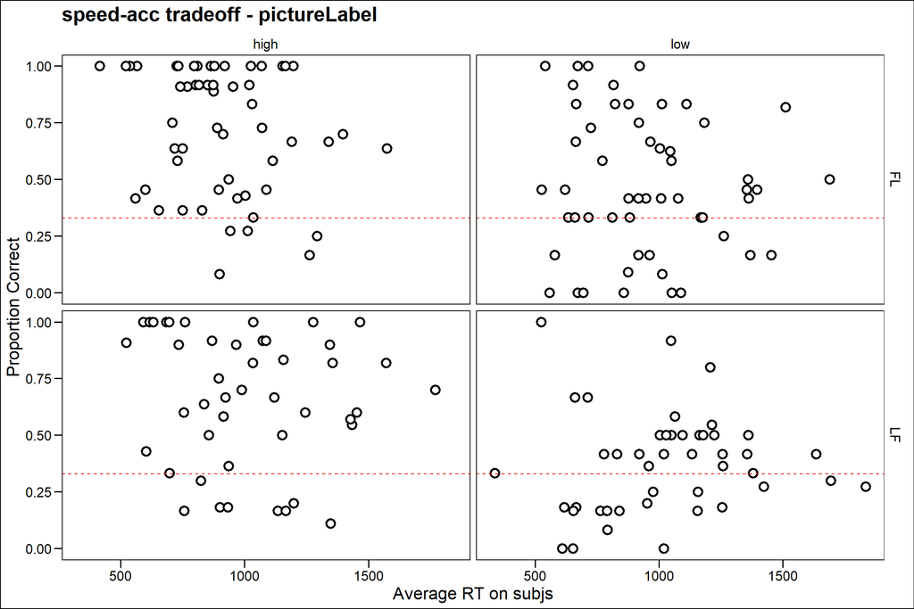

```r
aggregate(acc ~ subjID+learning+frequency, pictureLabel[pictureLabel$rt > 100  &
                                         !(pictureLabel$subjID %in% badsubjs),], mean)-> speedacc
aggregate(rt ~ subjID+learning+frequency, pictureLabel[pictureLabel$rt > 100  &
                                         !(pictureLabel$subjID %in% badsubjs),], mean)-> speedacc2
merge(speedacc, speedacc2, by =  c("subjID", "learning", "frequency"))-> speedacc
rm(speedacc2)
dplyr::recode(speedacc$frequency, "25"="low", "75"="high")-> speedacc$frequency;

ggplot(aes(x=rt, y=acc),
           data = speedacc) +
  facet_grid( learning ~ frequency) +
  geom_point( shape = 21, fill = "white", size = 3, stroke = 1.5) +
  #geom_smooth(method = "lm", formula = y ~ poly(x,2), se = TRUE, color = "#0892d0", fill = "lightgray") +
  geom_hline(yintercept = 0.33, lty = "dashed", color = 'red') +
  coord_cartesian(ylim = c(0, 1))+
  ggthemes::theme_base()+
  xlab("Average RT on subjs") +
  ylab("Proportion Correct") +
  ggtitle("speed-acc tradeoff - pictureLabel")
```

```r
speedacc %>%
  group_by(frequency, learning) %>%
  summarise(mean(rt), median(rt))
```

```
## # A tibble: 4 x 4
## # Groups:   frequency [2]
##   frequency learning `mean(rt)` `median(rt)`
##   <chr>     <fct>         <dbl>        <dbl>
## 1 high      FL             911.         892.
## 2 high      LF            1016.         966.
## 3 low       FL             948.         918.
## 4 low       LF            1028.        1029.
```

## Final Comparisons

Barplot labelPicture

```r
ms <- aggregate(acc ~ subjID+frequency+learning,
                data=labelPicture[labelPicture$rt > 100  &
                                         !(labelPicture$subjID %in% badsubjs),], FUN= mean)

df<- ms %>%
  group_by(frequency, learning)%>%
  summarise(
    mean = mean(acc),
    sd = sd(acc),
    n = n()) %>%
  mutate( se=sd/sqrt(n))  %>%
  mutate( ci=se * qt((1-0.05)/2 + .5, n-1))

df$frequency <- as.factor(df$frequency)
plyr::revalue(df$frequency, c("25"="low"))-> df$frequency;
plyr::revalue(df$frequency, c("75"="high"))-> df$frequency;


lp<-ggplot(aes(x = frequency, y = mean, fill = frequency), data = df) +
  facet_grid( . ~ learning) +
  geom_bar(stat = "identity", color='white', position=position_dodge(), size=1.2) +
  geom_errorbar(aes(ymin=mean-se, ymax=mean+se), width=.15, size=1,position=position_dodge(.9)) +
  ylab("Accuracy ") +
  xlab("frequency") +
  ggtitle("labelPictures") +
  coord_cartesian(ylim = c(0, 1))+
  ggpubr::theme_pubclean() +
  theme(legend.position = "none")  +
  theme(text = element_text(size=10)) +
  geom_hline(yintercept = .33, col='red', lwd=1);
```

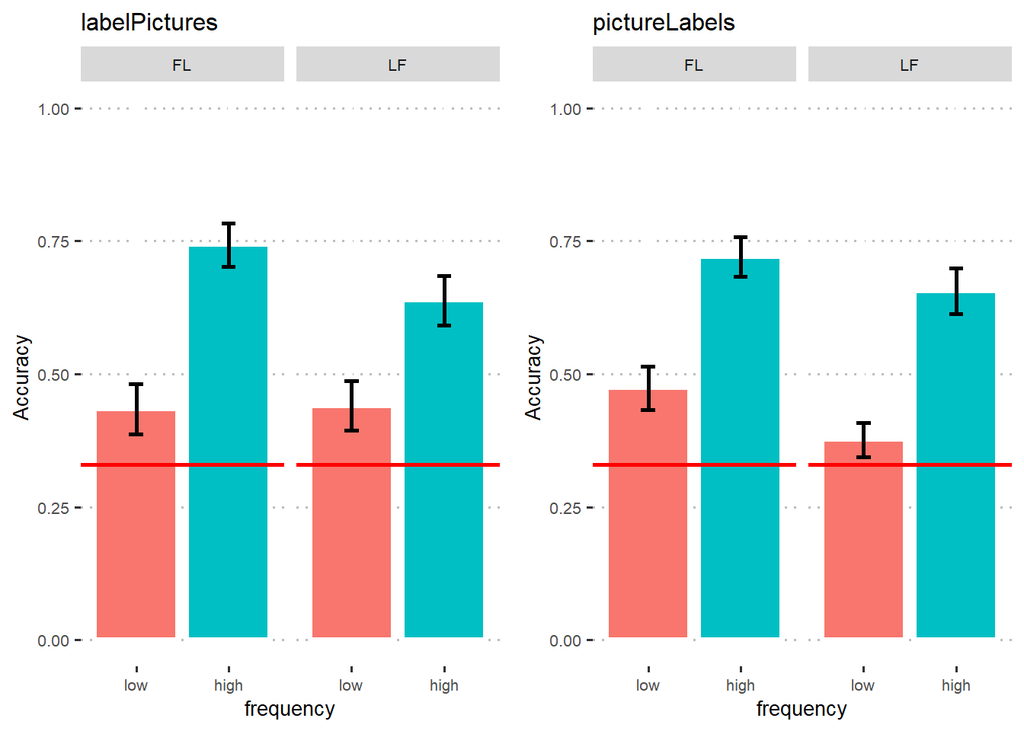

```r
grid.arrange(lp, pl, ncol=2)
```

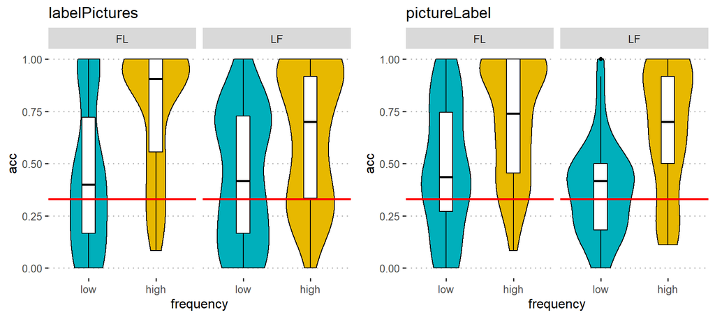

```r
ms <- aggregate(acc ~ subjID+frequency+learning,
                data=labelPicture[labelPicture$rt > 100  &
                                    labelPicture$rt <=2500 &
                                         !(labelPicture$subjID %in% badsubjs),], FUN= mean)

ms$frequency <- as.factor(ms$frequency)
plyr::revalue(ms$frequency, c("25"="low"))-> ms$frequency;
plyr::revalue(ms$frequency, c("75"="high"))-> ms$frequency;

lp_violin<- ggviolin(ms, x = "frequency", y = "acc", fill = "frequency",
         palette = c("#00AFBB", "#E7B800"),
         add = "boxplot",
         add.params = list(fill = "white"),
         trim=TRUE) +
         ggtitle('labelPictures') +
        facet_grid( . ~ learning) +
        theme_pubclean()+
  theme(legend.position = "none") +
  geom_hline(yintercept = .33, col='red', lwd=1);


ms <- aggregate(acc ~ subjID+frequency+learning,
                data=pictureLabel[pictureLabel$rt > 100  &
                                         !(pictureLabel$subjID %in% badsubjs),], FUN= mean)

ms$frequency <- as.factor(ms$frequency)
plyr::revalue(ms$frequency, c("25"="low"))-> ms$frequency;
plyr::revalue(ms$frequency, c("75"="high"))-> ms$frequency;

pl_violin<- ggviolin(ms, x = "frequency", y = "acc", fill = "frequency",
         palette = c("#00AFBB", "#E7B800"),
         add = "boxplot",
         add.params = list(fill = "white"),
         trim=TRUE) +
         ggtitle('pictureLabel') +
        facet_grid( . ~ learning) +
        theme_pubclean()+
  theme(legend.position = "none") +
  geom_hline(yintercept = .33, col='red', lwd=1);

grid.arrange(lp_violin, pl_violin, ncol=2)
```

```r
#rm(ms, ss_prop)
```

Barplots + violinPlots with data from both tasks:

```r
rm(ms, df, ss_prop)
genTask <- rbind(labelPicture, pictureLabel)
```

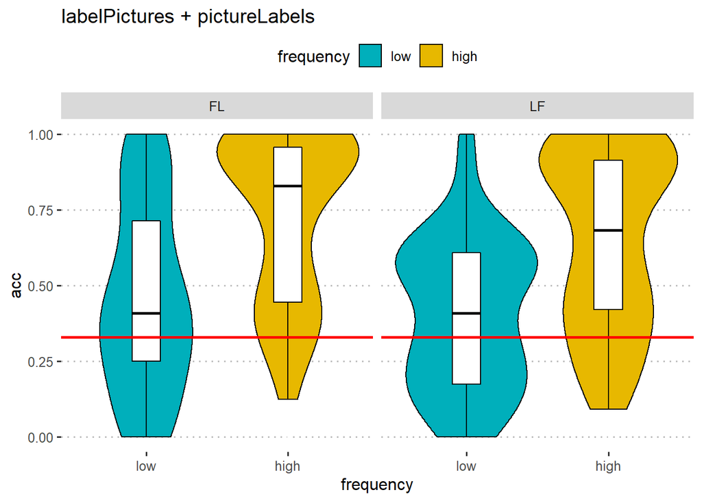

```r
ms <- aggregate(acc ~ subjID+frequency+learning, data = genTask[genTask$rt>100 &
                                         !(genTask$subjID %in% badsubjs),], mean)

ms$frequency <- as.factor(ms$frequency)
plyr::revalue(ms$frequency, c("25"="low"))-> ms$frequency;
plyr::revalue(ms$frequency, c("75"="high"))-> ms$frequency;

ggviolin(ms, x = "frequency", y = "acc", fill = "frequency",
         palette = c("#00AFBB", "#E7B800"),
         add = "boxplot",
         add.params = list(fill = "white"),
         trim=TRUE) +
        ggtitle('labelPictures + pictureLabels') +
        facet_grid( . ~ learning) +
        theme_pubclean()+
  geom_hline(yintercept = .33, col='red', lwd=1);
```

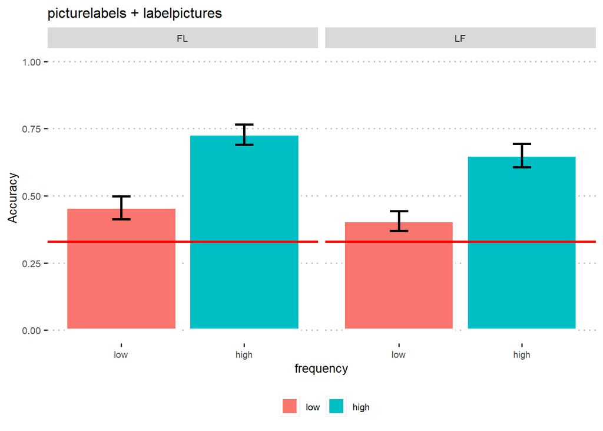

```r
ms <- aggregate(acc ~ subjID+frequency+learning, data=genTask[genTask$rt>100 &
                                         !(genTask$subjID %in% badsubjs),], FUN= mean)

df<- ms %>%
  group_by(frequency, learning)%>%
  summarise(
    mean = mean(acc),
    sd = sd(acc),
    n = n()) %>%
  mutate( se=sd/sqrt(n))  %>%
  mutate( ci=se * qt((1-0.05)/2 + .5, n-1))

df$frequency <- as.factor(df$frequency)
plyr::revalue(df$frequency, c("25"="low"))-> df$frequency;
plyr::revalue(df$frequency, c("75"="high"))-> df$frequency;


ggplot(aes(x = frequency, y = mean, fill = frequency), data = df) +
  facet_grid( . ~ learning) +
  geom_bar(stat = "identity", color='white', position=position_dodge(), size=1.2) +
  geom_errorbar(aes(ymin=mean-se, ymax=mean+se), width=.15, size=1,position=position_dodge(.9)) +
  ylab("Accuracy ") +
  xlab("frequency") +
  ggtitle("labelPicture") +
  ggtitle('picturelabels + labelpictures') +
  coord_cartesian(ylim = c(0, 1))+
  ggpubr::theme_pubclean() +
  theme(legend.position="bottom", legend.title = element_blank()) +
  theme(text = element_text(size=10)) +
  geom_hline(yintercept = .33, col='red', lwd=1);
```

# Task 3: Contingency judgement

```r
length(unique(contingencyJudgement$subjID))
```

```
## [1] 120
```

```r
fl<- length(unique(contingencyJudgement[contingencyJudgement$learning=='FL' ,]$subjID))

lf<- length(unique(contingencyJudgement[contingencyJudgement$learning=='LF' ,]$subjID))

fl
```

```
## [1] 63
```

```r
lf
```

```
## [1] 57
```

We have 63 for feature-label learning, and 57 for label-feature learning.

```r
rm(fl,lf)
conjudge <- contingencyJudgement[!(is.na(contingencyJudgement$resp)),]
n<- length(unique(conjudge$subjID))
nrows <- (nrow(contingencyJudgement)) - (nrow(conjudge))

sort(unique(conjudge$subjID))-> subjs;
sort(unique(contingencyJudgement$subjID)) ->totsubjs;

subjmissed<- setdiff(totsubjs, subjs);

badsubjs <- c(badsubjs, subjmissed)
badsubjs <- unique(badsubjs)

(nrow(contingencyJudgement[contingencyJudgement$learning=='LF',])) - (nrow(conjudge[conjudge$learning=='LF',]))
```

```
## [1] 301
```

We have 111 participants in this task, so -9, and we have missed 559 over the total 2880, that is 19.41%. The subject(s) that missed completely the task is/are: 1414932, 1420171, 1420199, 1422475, 1431960, 1431997, 1459020, 1459057, 1459078.

Distribution of the missing data across condition:

- LF learning, 22.003%
  - LF learning, Low freq: 23.392%
  - LF learning, High freq: 20.614%
- FL learning, 17.063%
  - FL learning, Low freq: 19.18%
  - FL learning, High freq: 14.947%

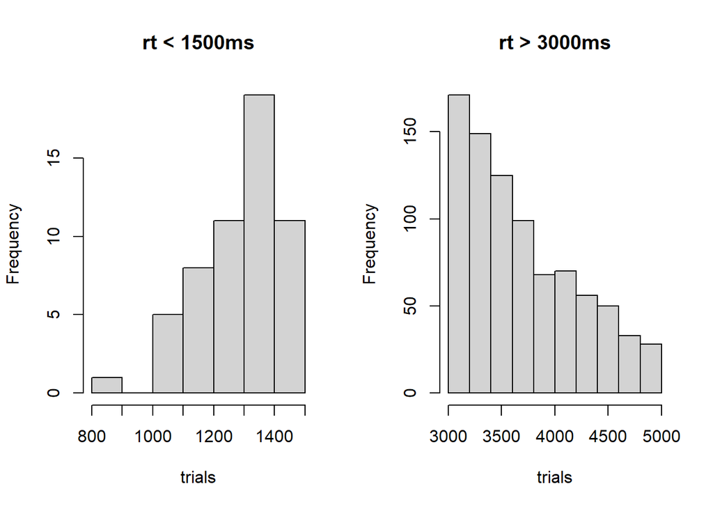

```r
par(mfrow=c(1,2))
hist(conjudge[conjudge$rt<1500 & !(conjudge$subjID %in% badsubjs),]$rt, main = 'rt < 1500ms', xlab = 'trials');
hist(conjudge[conjudge$rt>3000 & !(conjudge$subjID %in% badsubjs),]$rt, main = 'rt > 3000ms', xlab = 'trials');
```

```r
par(mfrow=c(1,1))
```

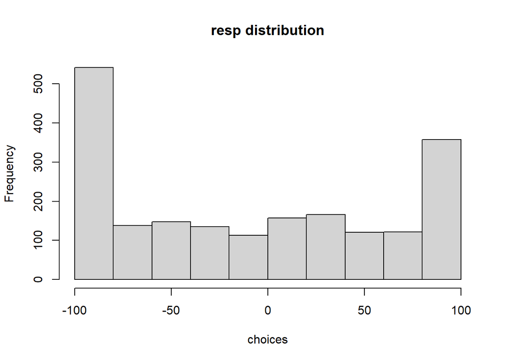

```r
hist(conjudge[!(conjudge$subjID %in% badsubjs),]$resp, main = 'resp distribution', xlab = 'choices')
```

Ok, here we don’t have right or wrong answers, but we are more interested in take a look how the participants rated the fribble label association:

```r
aggregate(resp ~ category, data = conjudge[!(conjudge$subjID %in% badsubjs),], FUN = mean)
```

```
##   category       resp
## 1        1 -12.119084
## 2        2  -6.564636
## 3        3 -10.635821
```

Okay, in this task one fribble was presented along with a label. The association between the fribble presented and the label could have been correct, or wrong. In this case then accuracy column does **not** refer to the participants’ accuracy, but rather to the fribble-label pair presented. This should be therefore necessarily equal to the chance level, i.e, around 33%, of course this number is dependent by the number of datapoints left without no-responses because we filtered out those.

```r
conjudge$acc <- 0;
conjudge[conjudge$category==1 & conjudge$label=='dep',]$acc <- 1;
conjudge[conjudge$category==2 & conjudge$label=='bim',]$acc <- 1;
conjudge[conjudge$category==3 & conjudge$label=='tob',]$acc <- 1;
```

```r
mean(conjudge[!(conjudge$subjID %in% badsubjs),]$acc)
```

```
## [1] 0.3523524
```

Quite there, everything good.

## save data

```r
write.table(conjudge, paste(localGitDir, "/exp1/data/conjudge.txt", sep = ""), col.names = T, row.names = F, quote = F)
```

## plot mean responses

```r
respDistr<- aggregate(resp ~ learning + frequency + category + label, data = conjudge[!(conjudge$subjID %in% badsubjs),], mean)
```

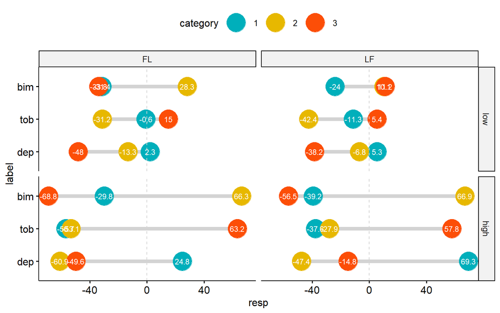

```r
plyr::revalue(as.factor(respDistr$frequency), c("25"="low"))-> respDistr$frequency;
plyr::revalue(as.factor(respDistr$frequency), c("75"="high"))-> respDistr$frequency;
respDistr$category <- as.factor(respDistr$category)

lollipop<-ggdotchart(respDistr, x = "label", y = "resp",
           color = "category",                                # Color by groups
           palette = c("#00AFBB", "#E7B800", "#FC4E07"), # Custom color palette
           add = "segments",                             # Add segments from y = 0 to dots
           rotate = T,
           add.params = list(color = "lightgray", size = 2), # Change segment color and size
           group = "category",                                # Order by groups
           dot.size = 10,                                 # Large dot size
           label = round(respDistr$resp,1),                        # Add mpg values as dot labels
           font.label = list(color = "white", size = 9,
                             vjust = 0.5),               # Adjust label parameters
           ggtheme = theme_pubr()                        # ggplot2 theme
           )+ facet_grid( frequency ~ learning) +
  geom_hline(yintercept = 0, linetype = 2, color = "lightgray")

lollipop
```

Plot to compare with RW weights:

```r
plyr::revalue(as.factor(conjudge$frequency), c("25"="low"))-> conjudge$frequency;
plyr::revalue(as.factor(conjudge$frequency), c("75"="high"))-> conjudge$frequency;
```

For each learning condition, look at their average score for each of the 6 combinations of frequency and type:

High frequency:

```r
highFreqFL<-data.frame(
           learning = rep("FL",9),
           frequency = rep("high",9),
           type = c(rep("match",3),
                    rep("mismatch-type1",3),
                    rep("mismatch-type2",3)),
           label = c("dep_cat1", "bim_cat2", "tob_cat3"),
           fribble = c(1.1,2.1,3.1,
                       3.1,1.1,2.1,
                       2.1,3.1,1.1),
           fribbleCategory = c("cat1", "cat2", "cat3", #match
                        "cat3", "cat1", "cat2", #mis-type1
                        "cat2", "cat3", "cat1")) #mis-type2

highFreqLF<-data.frame(
           learning = rep("LF",9),
           frequency = rep("high",9),
           type = c(rep("match",3),
                    rep("mismatch-type1",3),
                    rep("mismatch-type2",3)),
           label = c("dep_cat1", "bim_cat2", "tob_cat3"),
           fribble = c(1.1,2.1,3.1,
                       3.1,1.1,2.1,
                       2.1,3.1,1.1),
           fribbleCategory = c("cat1", "cat2", "cat3", #match
                        "cat3", "cat1", "cat2", #mis-type1
                        "cat2", "cat3", "cat1")) #mis-type2

rbind(highFreqFL, highFreqLF)-> highFreq
rm(highFreqFL, highFreqLF)
```

Low frequency:

```r
lowFreqFL<-data.frame(
           learning = rep("FL",9),
           frequency = rep("low",9),
           type = c(rep("match",3),
                    rep("mismatch-type1",3),
                    rep("mismatch-type2",3)),
           label = c("dep_cat1", "bim_cat2", "tob_cat3"),
           fribble = c(1.2,2.2,3.2,
                       2.2,3.2,1.2,
                       3.2,1.2,2.2),
           fribbleCategory = c("cat1", "cat2", "cat3", #match
                               "cat2", "cat3", "cat1", #mis-type1
                               "cat3", "cat1", "cat2")) #mis-type2

lowFreqLF<-data.frame(
           learning = rep("LF",9),
           frequency = rep("low",9),
           type = c(rep("match",3),
                    rep("mismatch-type1",3),
                    rep("mismatch-type2",3)),
           label = c("dep_cat1", "bim_cat2", "tob_cat3"),
           fribble = c(1.2,2.2,3.2,
                       2.2,3.2,1.2,
                       3.2,1.2,2.2),
           fribbleCategory = c("cat1", "cat2", "cat3", #match
                               "cat2", "cat3", "cat1", #mis-type1
                               "cat3", "cat1", "cat2")) #mis-type2
lowFreq<- rbind(lowFreqFL, lowFreqLF)
rm(lowFreqFL, lowFreqLF)
```

```r
rbind(highFreq, lowFreq)-> humansWeights
humansWeights$learning <- as.factor(humansWeights$learning); humansWeights$frequency <- as.factor(humansWeights$frequency); humansWeights$type <- as.factor(humansWeights$type); humansWeights$label <- as.factor(humansWeights$label); humansWeights$fribbleCategory <- as.factor(humansWeights$fribbleCategory)
rm(highFreq, lowFreq)
summary(humansWeights)
```

```
##  learning frequency             type         label       fribble
##  FL:18    high:18   match         :12   bim_cat2:12   Min.   :1.10
##  LF:18    low :18   mismatch-type1:12   dep_cat1:12   1st Qu.:1.20
##                     mismatch-type2:12   tob_cat3:12   Median :2.15
##                                                       Mean   :2.15
##                                                       3rd Qu.:3.10
##                                                       Max.   :3.20
##  fribbleCategory      resp
##  cat1:12         Min.   :-68.79
##  cat2:12         1st Qu.:-39.98
##  cat3:12         Median :-19.43
##                  Mean   :-11.04
##                  3rd Qu.: 10.34
##                  Max.   : 69.30
```

```r
dataWeight <- aggregate(resp ~ learning + frequency + type, data = humansWeights,FUN = mean)
```

Plot of human responses considered as summed weights of the label-feature association.

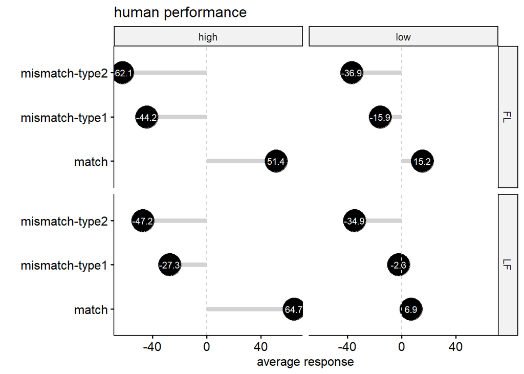

Summed weights of the label-feature association by frequency by learning

```r
lollipopWeight<-ggdotchart(dataWeight, x = "type", y = "resp",
           #color = "learning",                                # Color by groups
           palette = c("#00AFBB", "#E7B800", "#FC4E07"), # Custom color palette
           add = "segments",                             # Add segments from y = 0 to dots
           rotate = T,
           add.params = list(color = "lightgray", size = 2), # Change segment color and size
           #group = "learning",                                # Order by groups
           dot.size = 10,                                 # Large dot size
           label = round(dataWeight$resp,1),                        # Add mpg values as dot labels
           font.label = list(color = "white", size = 9,
                             vjust = 0.5),               # Adjust label parameters
           ggtheme = theme_pubr(),                        # ggplot2 theme
           title = "human performance",
           ylab = "average response",
           xlab = " "
           )+ facet_grid( learning ~ frequency) +
  geom_hline(yintercept = 0, linetype = 2, color = "lightgray")

lollipopWeight
```

```r
dataWeight$respZ.score <- as.vector(scale(dataWeight$resp))
head(dataWeight)
```

```
##   learning frequency           type       resp respZ.score
## 1       FL      high          match  51.436170   1.5772919
## 2       LF      high          match  64.678091   1.9115761
## 3       FL       low          match  15.190638   0.6622956
## 4       LF       low          match   6.902998   0.4530793
## 5       FL      high mismatch-type1 -44.191206  -0.8367626
## 6       LF      high mismatch-type1 -27.296453  -0.4102649
```

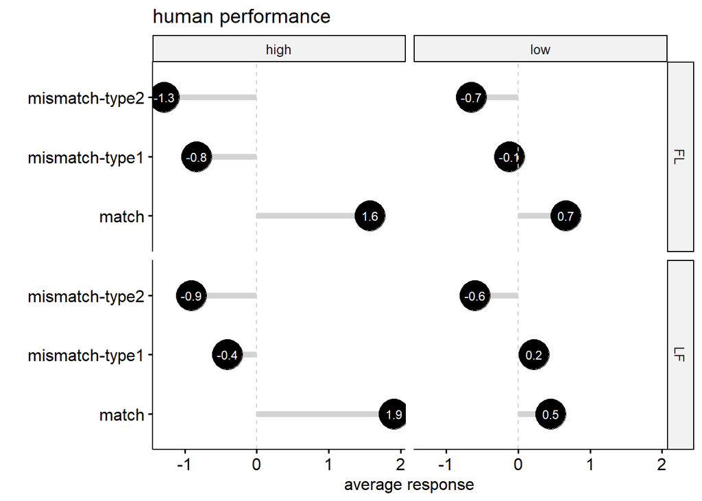

Z-score of the Summed weights of the label-feature association by frequency by learning

```r
lollipopWeightZ<-ggdotchart(dataWeight, x = "type", y = "respZ.score",
           #color = "learning",                                # Color by groups
           palette = c("#00AFBB", "#E7B800", "#FC4E07"), # Custom color palette
           add = "segments",                             # Add segments from y = 0 to dots
           rotate = T,
           add.params = list(color = "lightgray", size = 2), # Change segment color and size
           #group = "learning",                                # Order by groups
           dot.size = 10,                                 # Large dot size
           label = round(dataWeight$respZ.score,1),                        # Add mpg values as dot labels
           font.label = list(color = "white", size = 9,
                             vjust = 0.5),               # Adjust label parameters
           ggtheme = theme_pubr(),                        # ggplot2 theme
           title = "human performance",
           ylab = "average response",
           xlab = " "
           )+ facet_grid( learning ~ frequency) +
  geom_hline(yintercept = 0, linetype = 2, color = "lightgray")

lollipopWeightZ
```

What about having the same info by subject instead of the grand average?

```r
listSubj <-unique(conjudge[conjudge$learning=="FL" & !(conjudge$subjID %in% badsubjs),]$subjID)
```

For loop across participants for FL learning:

```r
rbind(lowFreqFL, highFreqFL)->humansWeights_FL
```

For loop across participants for LF learning:

```r
listSubj <-unique(conjudge[conjudge$learning=="LF" & !(conjudge$subjID %in% badsubjs),]$subjID)
```

```r
rbind(lowFreqLF, highFreqLF)->humansWeights_LF
rm(lowFreqLF, highFreqLF, lowFreqFL, highFreqFL)
```

```r
humansTypeWeigths<-rbind(humansWeights_FL, humansWeights_LF)
rm(humansWeights_FL, humansWeights_LF)
```

## RW comparison

How do we compare these measures with the RW?

```
## [1] "FL learning"
## [1] 0.3335453
## [1] 0.2218817
## [1] 0
## [1] 0.4996484
## [1] 0.3879108
## [1] 0
## [1] -0.1660331
## [1] -0.1660419
## [1] 0
```

```
## [1] "FL learning"
## [1] 0.3336234
## [1] 0.2219494
## [1] 0
## [1] 0.4996488
## [1] 0.3879235
## [1] 0
## [1] -0.1660696
## [1] -0.1660033
## [1] 0
```

```
## [1] "LF learning"
## [1] 0.751511
## [1] 0.2382185
## [1] 0
## [1] 0.7477625
## [1] 0.2315229
## [1] 0
## [1] 0
## [1] 0
## [1] 0
```

```
## [1] "LF learning"
## [1] 0.7560272
## [1] 0.2674515
## [1] 0
## [1] 0.7393796
## [1] 0.1950576
## [1] 0
## [1] 0
## [1] 0
## [1] 0
```

In the FLO paper there were 15 high freq exemplars, and 5 low frequency exemplar per category (proportion: 1/3). This is approximated here in this input where for every category/label, there are 3 high freq exemplars and 1 low freq exemplar. Frequency of presentation kept constant: 250.

```r
myexp
```

```
##            Cues Outcomes Frequency
## 1    blue_d1_i1      dep       250
## 2    blue_d1_i2      dep       250
## 3    blue_d1_i3      dep       250
## 4     red_d2_j1      dep       250
## 5  purple_d3_k1      bim       250
## 6  purple_d3_k2      bim       250
## 7  purple_d3_k3      bim       250
## 8    blue_d4_l1      bim       250
## 9     red_d5_x1      tob       250
## 10    red_d5_x2      tob       250
## 11    red_d5_x3      tob       250
## 12 purple_d6_y1      tob       250
```

For the label “dep” - category 1:

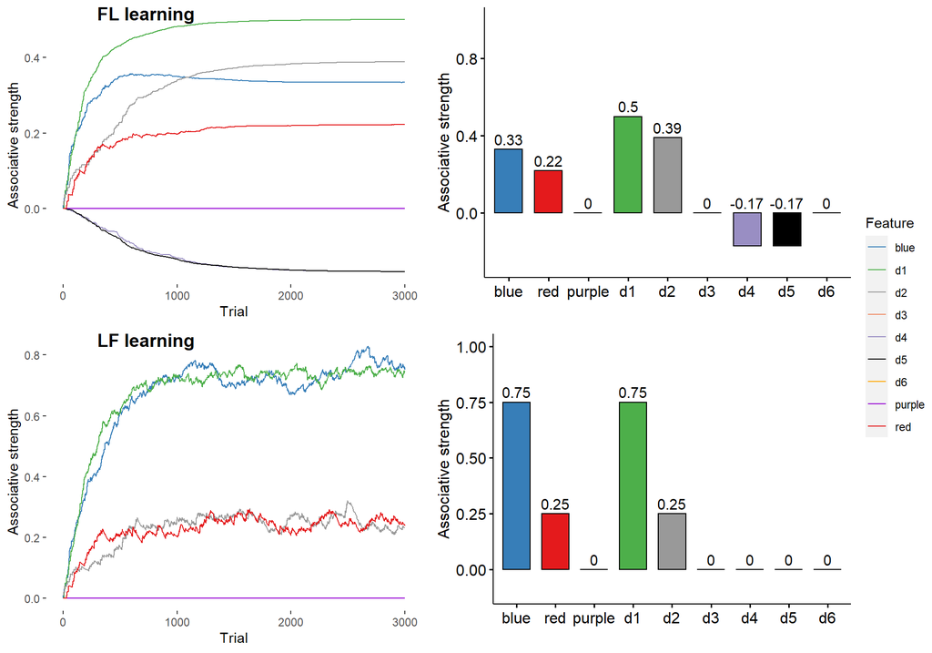

Let’s store the equilibrium weigths from the RW

```r
# label dep
equilibriumsFL<-data.frame(
  learning="FL",
  label=c(rep("dep",9),rep("bim",9),rep("tob",9)),
  singleCues=c("blue","red","purple","d1","d2","d3","d4","d5","d6"),
  Equilibriums=c(.33,.22,0,.5,.39,0,-.17,-.17,0,
                 .22,0,.33,-.17,0,.5,.39,0,-.17,
                 0,.33,.22,0,-.17,-.17,0,.5,.39)
)

equilibriumsLF<-data.frame(
  learning="LF",
  label=c(rep("dep",9),rep("bim",9),rep("tob",9)),
  singleCues=c("blue","red","purple","d1","d2","d3","d4","d5","d6"),
  Equilibriums=c(.75,.25,0,.75,.25,0,0,0,0,
                 .25,0,.75,0,0,.75,.25,0,0,
                 0,.75,.25,0,0,0,0,.75,.25)
)
```

Now let’s build a dataframe that looks like humans weights

```r
highFreqFL_modelWeights <-data.frame(
  learning = rep("FL",9),
  frequency = rep("high",9),
  type = c(rep("match",3),
           rep("mismatch-type1",3),
           rep("mismatch-type2",3)),
  label = c("dep_cat1", "bim_cat2", "tob_cat3"),
  fribble = c(1.1,2.1,3.1,
              3.1,1.1,2.1,
              2.1,3.1,1.1),
  fribbleCategory = c("cat1", "cat2", "cat3", #match
                      "cat3", "cat1", "cat2", #mis-type1
                      "cat2", "cat3", "cat1")) #mis-type2

highFreqLF_modelWeights<-data.frame(
           learning = rep("LF",9),
           frequency = rep("high",9),
           type = c(rep("match",3),
                    rep("mismatch-type1",3),
                    rep("mismatch-type2",3)),
           label = c("dep_cat1", "bim_cat2", "tob_cat3"),
           fribble = c(1.1,2.1,3.1,
                       3.1,1.1,2.1,
                       2.1,3.1,1.1),
           fribbleCategory = c("cat1", "cat2", "cat3", #match
                        "cat3", "cat1", "cat2", #mis-type1
                        "cat2", "cat3", "cat1")) #mis-type2
```

```r
lowFreqFL_modelWeights<-data.frame(
           learning = rep("FL",9),
           frequency = rep("low",9),
           type = c(rep("match",3),
                    rep("mismatch-type1",3),
                    rep("mismatch-type2",3)),
           label = c("dep_cat1", "bim_cat2", "tob_cat3"),
           fribble = c(1.2,2.2,3.2,
                       2.2,3.2,1.2,
                       3.2,1.2,2.2),
           fribbleCategory = c("cat1", "cat2", "cat3", #match
                               "cat2", "cat3", "cat1", #mis-type1
                               "cat3", "cat1", "cat2")) #mis-type2

lowFreqLF_modelWeights<-data.frame(
           learning = rep("LF",9),
           frequency = rep("low",9),
           type = c(rep("match",3),
                    rep("mismatch-type1",3),
                    rep("mismatch-type2",3)),
           label = c("dep_cat1", "bim_cat2", "tob_cat3"),
           fribble = c(1.2,2.2,3.2,
                       2.2,3.2,1.2,
                       3.2,1.2,2.2),
           fribbleCategory = c("cat1", "cat2", "cat3", #match
                               "cat2", "cat3", "cat1", #mis-type1
                               "cat3", "cat1", "cat2")) #mis-type2
```

```
##   learning frequency           type    label fribble fribbleCategory
## 1       FL      high          match dep_cat1     1.1            cat1
## 2       FL      high          match bim_cat2     2.1            cat2
## 3       FL      high          match tob_cat3     3.1            cat3
## 4       FL      high mismatch-type1 dep_cat1     3.1            cat3
## 5       FL      high mismatch-type1 bim_cat2     1.1            cat1
## 6       FL      high mismatch-type1 tob_cat3     2.1            cat2
##   equilibriumWeigths
## 1               0.83
## 2               0.83
## 3               0.83
## 4               0.05
## 5               0.05
## 6               0.05
```

```r
modelWeight <- aggregate(equilibriumWeigths ~ learning + frequency + type, data = modelWeights,FUN = mean)
head(modelWeight)
```

```
##   learning frequency           type equilibriumWeigths
## 1       FL      high          match               0.83
## 2       LF      high          match               1.50
## 3       FL       low          match               0.61
## 4       LF       low          match               0.50
## 5       FL      high mismatch-type1               0.05
## 6       LF      high mismatch-type1               0.25
```

okay, in order to compare human with model performance, the equilibrium weigths *I think* should be normalised over a 0 that is the average of the weights.

```r
modelWeight$equilibriumWeigthsZ.score <- as.vector(scale(modelWeight$equilibriumWeigths))
```

Plot of human and model responses considered as summed weights of the label-feature association.

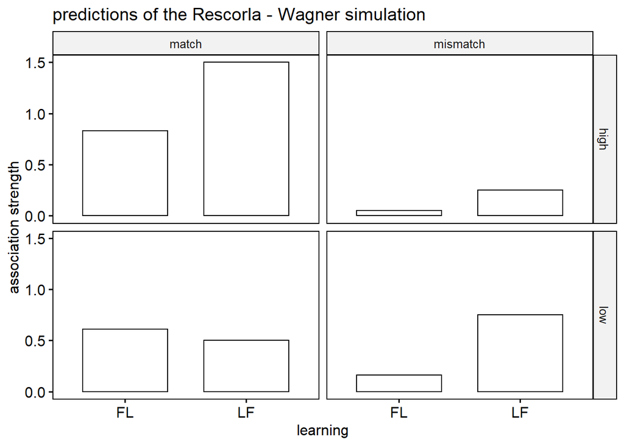

Summed weights of the label-feature association by frequency by learning

```r
lollipop_modelWeight<-ggdotchart(modelWeight, x = "type", y = "equilibriumWeigths",
           #color = "learning",                                # Color by groups
           palette = c("#00AFBB", "#E7B800", "#FC4E07"), # Custom color palette
           add = "segments",                             # Add segments from y = 0 to dots
           rotate = T,
           add.params = list(color = "lightgray", size = 2), # Change segment color and size
           #group = "learning",                                # Order by groups
           dot.size = 10,                                 # Large dot size
           label = round(modelWeight$equilibriumWeigths,1),                        # Add mpg values as dot labels
           font.label = list(color = "white", size = 9,
                             vjust = 0.5),               # Adjust label parameters
           ggtheme = theme_pubr(),                        # ggplot2 theme
           title = "model predictions",
           ylab = "association strength",
           xlab = " "
           )+ facet_grid( learning ~ frequency) +
  geom_hline(yintercept = 0, linetype = 2, color = "lightgray")

#lollipop_modelWeight #uncomment for this plot
modelWeight$type<-recode(modelWeight$type, "mismatch-type1" = "mismatch")

barplot_modelWeight<- ggbarplot(modelWeight[modelWeight$type!="mismatch-type2",], x = "learning",
      color = "black",
      #fill = "learning",
      y = "equilibriumWeigths",
      facet.by = c("frequency","type"),
      ylab = "association strength",
      position = position_dodge(.8),
      palette = c("#bdbdbd","#636363"),
      title = "predictions of the Rescorla - Wagner simulation"
      ) +
  theme(legend.position = "none")
barplot_modelWeight
```

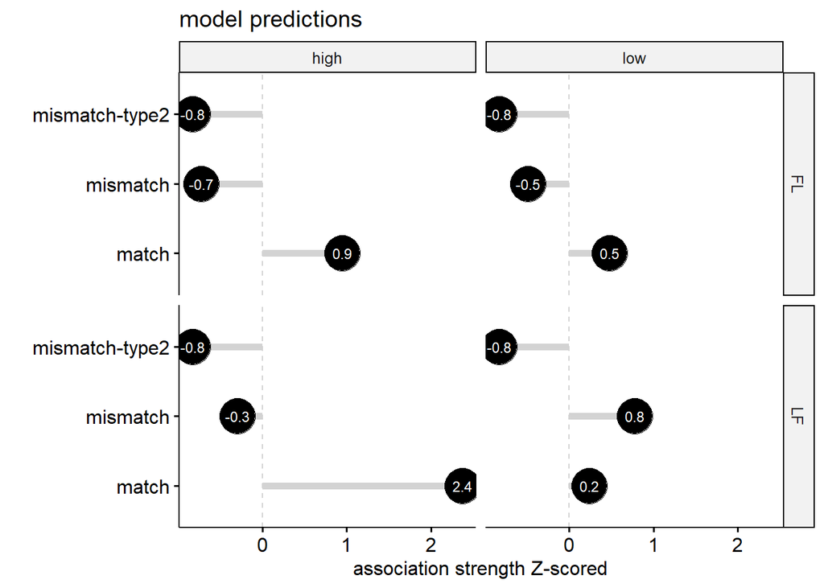

Summed weights of the label-feature association by frequency by learning

```r
lollipop_modelWeightZ<-ggdotchart(modelWeight, x = "type", y = "equilibriumWeigthsZ.score",
           #color = "learning",                                # Color by groups
           palette = c("#00AFBB", "#E7B800", "#FC4E07"), # Custom color palette
           add = "segments",                             # Add segments from y = 0 to dots
           rotate = T,
           add.params = list(color = "lightgray", size = 2), # Change segment color and size
           #group = "learning",                                # Order by groups
           dot.size = 10,                                 # Large dot size
           label = round(modelWeight$equilibriumWeigthsZ.score,1),                        # Add mpg values as dot labels
           font.label = list(color = "white", size = 9,
                             vjust = 0.5),               # Adjust label parameters
           ggtheme = theme_pubr(),                        # ggplot2 theme
           title = "model predictions",
           ylab = "association strength Z-scored",
           xlab = " "
           )+ facet_grid( learning ~ frequency) +
  geom_hline(yintercept = 0, linetype = 2, color = "lightgray")
lollipop_modelWeightZ
```

### Human and model performance

Raw data for humans and the model:

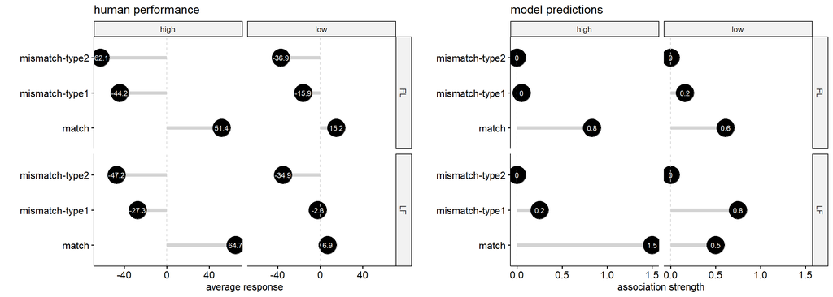

```r
ggarrange(lollipopWeight, lollipop_modelWeight)
```

Transformation in Z-scores for both humans and model performance:

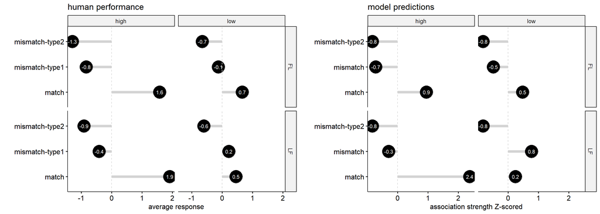

```r
ggarrange(lollipopWeightZ, lollipop_modelWeightZ)
```

```r
humansWeights$equilibriumWeigthsZ.score <- as.vector(scale(humansWeights$resp))
humansWeights$what <- as.factor(c("humans"))

modelWeights$equilibriumWeigthsZ.score <- as.vector(scale(modelWeights$equilibriumWeigths))
modelWeights$what <- as.factor(c("model"))

associationStrengths <- rbind(
  modelWeights[,c("learning","frequency","type","label","fribble",
                  "fribbleCategory","equilibriumWeigthsZ.score","what")],
  humansWeights[,c("learning","frequency","type","label","fribble",
                  "fribbleCategory","equilibriumWeigthsZ.score","what")])

summary(associationStrengths)
```

```
##  learning frequency             type       label           fribble
##  FL:36    high:36   match         :24   Length:72          1.1:12
##  LF:36    low :36   mismatch-type1:24   Class :character   1.2:12
##                     mismatch-type2:24   Mode  :character   2.1:12
##                                                            2.2:12
##                                                            3.1:12
##                                                            3.2:12
##  fribbleCategory equilibriumWeigthsZ.score     what
##  cat1:24         Min.   :-1.4519           model :36
##  cat2:24         1st Qu.:-0.8522           humans:36
##  cat3:24         Median :-0.3143
##                  Mean   : 0.0000
##                  3rd Qu.: 0.5378
##                  Max.   : 2.4466
```

Barplot

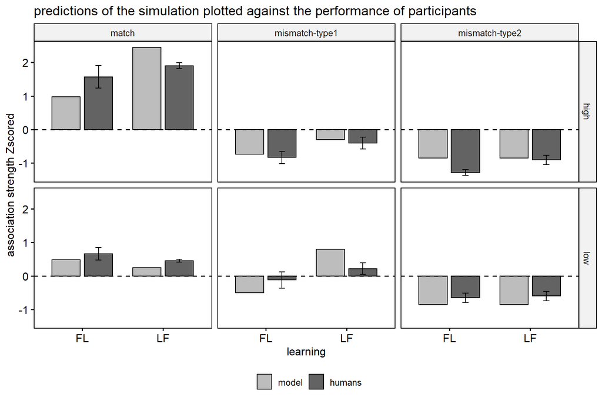

### save data

```r
write.table(humansTypeWeigths, paste(localGitDir, "/exp1/data/humansTypeWeigths.txt", sep = ""), col.names = T, row.names = F, quote = F)
```

# Analysis on response type

### Contingency Judgement task:

```r
relevel(humansTypeWeigths$type, ref = "mismatch-type1")->humansTypeWeigths$type
lm1<-lmer(resp ~  type * frequency * learning  +(frequency|subjID), data = humansTypeWeigths[!(humansTypeWeigths$type=="mismatch-type2"),])
car::Anova(lm1)
```

```
## Analysis of Deviance Table (Type II Wald chisquare tests)
##
## Response: resp
##                           Chisq Df Pr(>Chisq)
## type                    79.0590  1  < 2.2e-16 ***
## frequency                1.2171  1     0.2699
## learning                 1.5121  1     0.2188
## type:frequency          42.2081  1  8.206e-11 ***
## type:learning            1.3205  1     0.2505
## frequency:learning       0.8495  1     0.3567
## type:frequency:learning  1.6299  1     0.2017
## ---
## Signif. codes:  0 '***' 0.001 '**' 0.01 '*' 0.05 '.' 0.1 ' ' 1
```

```r
summary(lm1)
```

```
## Linear mixed model fit by REML. t-tests use Satterthwaite's method [
## lmerModLmerTest]
## Formula: resp ~ type * frequency * learning + (frequency | subjID)
##    Data: humansTypeWeigths[!(humansTypeWeigths$type == "mismatch-type2"),
##     ]
##
## REML criterion at convergence: 4043.6
##
## Scaled residuals:
##     Min      1Q  Median      3Q     Max
## -2.3792 -0.5743  0.0291  0.6066  2.5232
##
## Random effects:
##  Groups   Name          Variance Std.Dev. Corr
##  subjID   (Intercept)   1578     39.72
##           frequencyhigh 2993     54.71    -0.84
##  Residual               2483     49.83
## Number of obs: 374, groups:  subjID, 95
##
## Fixed effects:
##                                    Estimate Std. Error      df t value Pr(>|t|)
## (Intercept)                         -10.518     10.477 128.883  -1.004 0.317291
## typematch                            24.864     12.698 282.983   1.958 0.051211
## frequencyhigh                       -32.784     13.929 187.886  -2.354 0.019623
## learningLF                           17.270     15.821 138.077   1.092 0.276900
## typematch:frequencyhigh              68.250     17.388 322.152   3.925 0.000106
## typematch:learningLF                -32.320     18.816 281.966  -1.718 0.086955
## frequencyhigh:learningLF             -1.793     20.811 191.975  -0.086 0.931436
## typematch:frequencyhigh:learningLF   32.843     25.725 316.672   1.277 0.202648
##
## (Intercept)
## typematch                          .
## frequencyhigh                      *
## learningLF
## typematch:frequencyhigh            ***
## typematch:learningLF               .
## frequencyhigh:learningLF
## typematch:frequencyhigh:learningLF
## ---
## Signif. codes:  0 '***' 0.001 '**' 0.01 '*' 0.05 '.' 0.1 ' ' 1
##
## Correlation of Fixed Effects:
##             (Intr) typmtc frqncy lrnnLF typmt: typ:LF frq:LF
## typematch   -0.623
## frequncyhgh -0.773  0.467
## learningLF  -0.662  0.413  0.512
## typmtch:frq  0.449 -0.744 -0.612 -0.298
## typmtch:lLF  0.421 -0.675 -0.315 -0.649  0.502
## frqncyhg:LF  0.517 -0.312 -0.669 -0.781  0.410  0.492
## typmtch::LF -0.304  0.503  0.414  0.469 -0.676 -0.746 -0.629
```

```r
lm1.emm <- emmeans(lm1 , ~ type |frequency| learning )
contrast(lm1.emm, "consec",  simple = "each", combine = T, adjust = "bonferroni")
```

```
##  frequency learning type           contrast               estimate   SE  df
##  low       FL       .              match - mismatch-type1    24.86 12.8 281
##  high      FL       .              match - mismatch-type1    93.11 11.8 258
##  low       LF       .              match - mismatch-type1    -7.46 14.0 279
##  high      LF       .              match - mismatch-type1    93.64 12.8 229
##  .         FL       mismatch-type1 high - low               -32.78 14.0 190
##  .         FL       match          high - low                35.47 14.2 120
##  .         LF       mismatch-type1 high - low               -34.58 15.5 198
##  .         LF       match          high - low                66.52 15.0 104
##  low       .        mismatch-type1 LF - FL                   17.27 15.9 134
##  low       .        match          LF - FL                  -15.05 14.9 112
##  high      .        mismatch-type1 LF - FL                   15.48 13.1 126
##  high      .        match          LF - FL                   16.00 13.2 125
##  t.ratio p.value
##   1.937  0.6457
##   7.910  <.0001
##  -0.531  1.0000
##   7.343  <.0001
##  -2.341  0.2431
##   2.493  0.1686
##  -2.224  0.3273
##   4.437  0.0003
##   1.085  1.0000
##  -1.012  1.0000
##   1.182  1.0000
##   1.214  1.0000
##
## Degrees-of-freedom method: kenward-roger
## P value adjustment: bonferroni method for 12 tests
```

### Picture label task

```r
df<-aggregate(acc ~ frequency + learning + subjID, data = pictureLabel_respType, mean)
```

```r
lm2<-lmer(acc ~  frequency * learning + (1|subjID), data = df)
car::Anova(lm2)
```

```
## Analysis of Deviance Table (Type II Wald chisquare tests)
##
## Response: acc
##                      Chisq Df Pr(>Chisq)
## frequency          48.6566  1  3.049e-12 ***
## learning            3.2245  1    0.07254 .
## frequency:learning  0.0066  1    0.93545
## ---
## Signif. codes:  0 '***' 0.001 '**' 0.01 '*' 0.05 '.' 0.1 ' ' 1
```

```r
summary(lm2)$coefficients
```

```
##                              Estimate Std. Error        df     t value
## (Intercept)               0.429242424 0.03356626 196.80375 12.78791395
## frequencyhigh             0.237121212 0.04558184  98.99994  5.20209829
## learningLF               -0.062834557 0.04973759 196.80375 -1.26332139
## frequencyhigh:learningLF -0.005470073 0.06754195  98.99994 -0.08098779
##                              Pr(>|t|)
## (Intercept)              1.190887e-27
## frequencyhigh            1.065764e-06
## learningLF               2.079682e-01
## frequencyhigh:learningLF 9.356152e-01
```

```r
rm(df)
```

### Label picture task

```r
df<-aggregate(acc ~  frequency + learning + subjID, data = labelPicture_respType, mean)
```

```r
lm3<-lmer(acc ~   frequency * learning + (1|subjID), data = df)
car::Anova(lm3)
```

```
## Analysis of Deviance Table (Type II Wald chisquare tests)
##
## Response: acc
##                      Chisq Df Pr(>Chisq)
## frequency          31.1902  1  2.339e-08 ***
## learning            1.8628  1     0.1723
## frequency:learning  0.9516  1     0.3293
## ---
## Signif. codes:  0 '***' 0.001 '**' 0.01 '*' 0.05 '.' 0.1 ' ' 1
```

```r
summary(lm3)$coefficients
```

```
##                             Estimate Std. Error        df    t value
## (Intercept)               0.42248677 0.03940969 193.57353 10.7203769
## frequencyhigh             0.26020723 0.05441000  96.99999  4.7823422
## learningLF               -0.01835979 0.05845402 193.57353 -0.3140894
## frequencyhigh:learningLF -0.07872575 0.08070307  96.99999 -0.9754988
##                              Pr(>|t|)
## (Intercept)              2.388783e-21
## frequencyhigh            6.180321e-06
## learningLF               7.537914e-01
## frequencyhigh:learningLF 3.317394e-01
```

```r
rm(df)
```

Clean the global environment:

```r
rm( problematicPeople, frequency, dumbPeople,  task, temp,  p, ms, n, nrows, subjs, totsubjs ,genTask, fribbleSet, alltasks, subjmissed, df)
```

# Bayes factor calculation with GLMMs

## Estimates of the betas from the original FLO paper

```r
#means
highfreq_mean<- mean(88, 98)
lowfreq_mean <- mean(38, 78)

n <- c(32)

#sd
highfreq_sd <- c(5*sqrt(n))

lowfreq_sd <- c(5*sqrt(n))
```

Main effect of frequency:

```r
frequency_beta<- logodds(highfreq_mean) - logodds(lowfreq_mean)
```

Main effect of learning:

```r
#mean
LF_mean <- mean(38, 88)
FL_mean <- mean(78, 98)

n <- c(16)

#sd
LF_sd <- c(5*sqrt(n)) #how can be possible that learnings have the same se?
FL_sd <- c(5*sqrt(n))
```

```r
learning_beta <- logodds(FL_mean) - logodds(LF_mean)
#positive > higher in the FL
```

Interaction between freq and learning:

Frequency effect (high-low) is greater in the LF than in FL:

```r
#(logodds(highfreq_FL)-logodds(lowfreq_FL))- (logodds(highfreq_LF)-logodds(lowfreq_LF))
freqBylearning_beta <- (logodds(98)-logodds(78))- (logodds(88)-logodds(38))*-1
```

## GLMMs with all tests separately

Picture label

```r
pictureLabel$frequency <- as.factor(pictureLabel$frequency)
plyr::revalue(pictureLabel$frequency, c("25"="low"))-> pictureLabel$frequency;
plyr::revalue(pictureLabel$frequency, c("75"="high"))-> pictureLabel$frequency;

pictureLabel$learning = relevel(pictureLabel$learning, ref = "LF")
pictureLabel$frequency = relevel(pictureLabel$frequency, ref = "low")
pictureLabel <- lizCenter(pictureLabel, list("learning" , "frequency", "task"))
```

```r
summarySEwithin(data = pictureLabel[pictureLabel$rt > 100 & !(pictureLabel$subjID %in% badsubjs),], measurevar = "acc", betweenvars = "learning", withinvars = "frequency", idvar = "subjID", conf.interval = .95)
```

```
##   learning frequency   N       acc  acc_norm        sd         se         ci
## 1       FL      high 582 0.7079038 0.6729505 0.5831509 0.02417238 0.04747590
## 2       FL       low 611 0.4877250 0.4550235 0.6269022 0.02536175 0.04980694
## 3       LF      high 465 0.6688172 0.7084257 0.5947813 0.02758232 0.05420174
## 4       LF       low 494 0.3785425 0.4228856 0.6642473 0.02988590 0.05871944
```

```r
piclab_model <- glmer(acc ~  frequency.ct*learning.ct + (frequency.ct|subjID),
         data = pictureLabel[pictureLabel$rt > 100 & !(pictureLabel$subjID %in% badsubjs),],
         family="binomial",
         control=glmerControl(optimizer = "bobyqa"))

adjusted.piclab_model = adjust_intercept_model(piclab_model, chance = log(0.33/(1-0.33)))
round(adjusted.piclab_model,5)
```

```
##                          Estimate Std. Error  z value Pr(>|z|)
## (Intercept)               1.15042    0.12498  9.20512  0.00000
## frequency.ct              1.54469    0.24235  6.37390  0.00000
## learning.ct               0.46486    0.24742  1.87883  0.06027
## frequency.ct:learning.ct -0.18451    0.47899 -0.38521  0.70008
```

```r
piclab_model2 <- glmer(acc ~  frequency*learning+ (frequency|subjID),
         data = pictureLabel[pictureLabel$rt > 100 & !(pictureLabel$subjID %in% badsubjs),],
         family="binomial",
         control=glmerControl(optimizer = "bobyqa"))

adjusted.piclab_model = adjust_intercept_model(piclab_model2, chance = log(0.33/(1-0.33)))


piclab_model.emm <- emmeans(piclab_model2 , ~ frequency* learning )
contrast(piclab_model.emm, "consec",  simple = "each", combine = F, adjust = "bonferroni")
```

```
## $`simple contrasts for frequency`
## learning = LF:
##  contrast   estimate    SE  df z.ratio p.value
##  high - low     1.64 0.354 Inf 4.645   <.0001
##
## learning = FL:
##  contrast   estimate    SE  df z.ratio p.value
##  high - low     1.46 0.328 Inf 4.448   <.0001
##
## Results are given on the log odds ratio (not the response) scale.
##
## $`simple contrasts for learning`
## frequency = low:
##  contrast estimate    SE  df z.ratio p.value
##  FL - LF     0.555 0.298 Inf 1.865   0.0622
##
## frequency = high:
##  contrast estimate    SE  df z.ratio p.value
##  FL - LF     0.370 0.387 Inf 0.957   0.3386
##
## Results are given on the log odds ratio (not the response) scale.
```

Label picture

```r
labelPicture$frequency <- as.factor(labelPicture$frequency)
plyr::revalue(labelPicture$frequency, c("25"="low"))-> labelPicture$frequency;
plyr::revalue(labelPicture$frequency, c("75"="high"))-> labelPicture$frequency;

labelPicture$learning = relevel(labelPicture$learning, ref = "LF")
labelPicture$frequency = relevel(labelPicture$frequency, ref = "low")
labelPicture <- lizCenter(labelPicture, list("learning" , "frequency", "task"))
```

```r
summarySEwithin(data = labelPicture[labelPicture$rt > 100 & labelPicture$rt <=2500 & !(labelPicture$subjID %in% badsubjs),], measurevar = "acc", betweenvars = "learning", withinvars = "frequency", idvar = "subjID", conf.interval = .95)
```

```
##   learning frequency   N       acc  acc_norm        sd         se         ci
## 1       FL      high 586 0.7440273 0.7151810 0.5322962 0.02198895 0.04318691
## 2       FL       low 554 0.4458484 0.4244508 0.5849702 0.02485300 0.04881783
## 3       LF      high 484 0.6508264 0.6784148 0.6177757 0.02808071 0.05517544
## 4       LF       low 460 0.4304348 0.4639248 0.6508264 0.03034494 0.05963222
```

```r
labpic_model <- glmer(acc ~  frequency.ct*learning.ct + (frequency.ct|subjID),
         data = labelPicture[labelPicture$rt > 100 & labelPicture$rt <=2500 & !(labelPicture$subjID %in% badsubjs),],
         family="binomial",
         control=glmerControl(optimizer = "bobyqa"))

adjusted.labpic_model = adjust_intercept_model(labpic_model, chance = log(0.33/(1-0.33)))
round(adjusted.labpic_model,5)
```

```
##                          Estimate Std. Error z value Pr(>|z|)
## (Intercept)               1.32254    0.17272 7.65720  0.00000
## frequency.ct              1.94468    0.35298 5.50936  0.00000
## learning.ct               0.51646    0.33501 1.54163  0.12316
## frequency.ct:learning.ct  0.59238    0.68714 0.86208  0.38864
```

```r
labpic_model2 <- glmer(acc ~  frequency*learning + (frequency|subjID),
         data = labelPicture[labelPicture$rt > 100 & labelPicture$rt <=2500 & !(labelPicture$subjID %in% badsubjs),],
         family="binomial",
         control=glmerControl(optimizer = "bobyqa"))

adjusted.labpic_model = adjust_intercept_model(labpic_model2, chance = log(0.33/(1-0.33)))

labpic_model.emm <- emmeans(labpic_model2, ~ frequency* learning )
contrast(labpic_model.emm, "consec",  simple = "each", combine = F, adjust = "bonferroni")
```

```
## $`simple contrasts for frequency`
## learning = LF:
##  contrast   estimate    SE  df z.ratio p.value
##  high - low     1.62 0.494 Inf 3.286   0.0010
##
## learning = FL:
##  contrast   estimate    SE  df z.ratio p.value
##  high - low     2.20 0.462 Inf 4.765   <.0001
##
## Results are given on the log odds ratio (not the response) scale.
##
## $`simple contrasts for learning`
## frequency = low:
##  contrast estimate    SE  df z.ratio p.value
##  FL - LF     0.215 0.461 Inf 0.465   0.6416
##
## frequency = high:
##  contrast estimate    SE  df z.ratio p.value
##  FL - LF     0.792 0.475 Inf 1.668   0.0953
##
## Results are given on the log odds ratio (not the response) scale.
```

Contingency judgement

```r
conjudge$learning = relevel(conjudge$learning, ref = "FL")
conjudge$frequency = relevel(conjudge$frequency, ref = "low")
conjudge <- lizCenter(conjudge, list("learning" , "frequency"))
```

```r
conjudge_model <- lmer(resp ~  learning.ct * frequency.ct +(frequency.ct|subjID),
         data = conjudge[!(conjudge$subjID %in% badsubjs) & conjudge$acc==0,])
```

```r
summary(conjudge_model)
```

```
## Linear mixed model fit by REML. t-tests use Satterthwaite's method [
## lmerModLmerTest]
## Formula: resp ~ learning.ct * frequency.ct + (frequency.ct | subjID)
##    Data: conjudge[!(conjudge$subjID %in% badsubjs) & conjudge$acc == 0,      ]
##
## REML criterion at convergence: 13831
##
## Scaled residuals:
##     Min      1Q  Median      3Q     Max
## -3.0126 -0.5456 -0.0994  0.5287  3.7574
##
## Random effects:
##  Groups   Name         Variance Std.Dev. Corr
##  subjID   (Intercept)  1379     37.13
##           frequency.ct 2387     48.85    0.06
##  Residual              2057     45.36
## Number of obs: 1294, groups:  subjID, 74
##
## Fixed effects:
##                          Estimate Std. Error      df t value Pr(>|t|)
## (Intercept)               -33.670      4.536  69.936  -7.424 2.11e-10 ***
## learning.ct                10.921      9.121  70.006   1.197  0.23524
## frequency.ct              -21.358      6.295  71.259  -3.393  0.00113 **
## learning.ct:frequency.ct   10.654     12.664  71.421   0.841  0.40299
## ---
## Signif. codes:  0 '***' 0.001 '**' 0.01 '*' 0.05 '.' 0.1 ' ' 1
##
## Correlation of Fixed Effects:
##             (Intr) lrnng. frqnc.
## learning.ct 0.028
## frequncy.ct 0.044  0.001
## lrnng.ct:f. 0.001  0.044  0.032
```

```r
conjudge_model2 <- lmer(resp ~  learning * frequency +(frequency|subjID),
         data = conjudge[!(conjudge$subjID %in% badsubjs) & conjudge$acc==0,])

conjudge_model.emm <- emmeans(conjudge_model2 , ~ learning* frequency )
contrast(conjudge_model.emm, "consec",  simple = "each", combine = F, adjust = "bonferroni")
```

```
## $`simple contrasts for learning`
## frequency = low:
##  contrast estimate   SE   df t.ratio p.value
##  LF - FL      5.48 11.0 70.9 0.500   0.6187
##
## frequency = high:
##  contrast estimate   SE   df t.ratio p.value
##  LF - FL     16.13 11.2 71.8 1.434   0.1559
##
## Degrees-of-freedom method: kenward-roger
##
## $`simple contrasts for frequency`
## learning = FL:
##  contrast   estimate   SE df t.ratio p.value
##  high - low    -26.3 8.44 70 -3.111  0.0027
##
## learning = LF:
##  contrast   estimate   SE df t.ratio p.value
##  high - low    -15.6 9.45 72 -1.652  0.1030
##
## Degrees-of-freedom method: kenward-roger
```

## Combine both generalization tasks in one dataset

I’m going to combine both generalization tasks in one single dataset called genTask

```r
genTask <- rbind(labelPicture[labelPicture$rt > 100 & !(labelPicture$subjID %in% badsubjs),],
                 pictureLabel[pictureLabel$rt > 100 & !(pictureLabel$subjID %in% badsubjs),])
genTask$frequency <- as.factor(genTask$frequency)
plyr::revalue(genTask$frequency, c("25"="low"))-> genTask$frequency;
plyr::revalue(genTask$frequency, c("75"="high"))-> genTask$frequency;
```

Relevel the variables:

```r
genTask$learning = relevel(genTask$learning, ref = "LF")
genTask$frequency = relevel(genTask$frequency, ref = "low")
genTask <- lizCenter(genTask, list("learning" , "frequency", "task"))
```

## The model

```r
genTask_model <- glmer(acc ~  frequency.ct*learning.ct + task.ct + (frequency.ct|subjID) ,
         data = genTask,
         family="binomial",
         control=glmerControl(optimizer = "bobyqa"))

adjusted.genTask_model = adjust_intercept_model(genTask_model, chance = log(0.33/(1-0.33)))
car::Anova(genTask_model)
```

```
## Analysis of Deviance Table (Type II Wald chisquare tests)
##
## Response: acc
##                            Chisq Df Pr(>Chisq)
## frequency.ct             41.2908  1  1.312e-10 ***
## learning.ct               2.9250  1    0.08721 .
## task.ct                   0.2106  1    0.64630
## frequency.ct:learning.ct  0.2949  1    0.58710
## ---
## Signif. codes:  0 '***' 0.001 '**' 0.01 '*' 0.05 '.' 0.1 ' ' 1
```

```r
summary(genTask_model)
```

```
## Generalized linear mixed model fit by maximum likelihood (Laplace
##   Approximation) [glmerMod]
##  Family: binomial  ( logit )
## Formula: acc ~ frequency.ct * learning.ct + task.ct + (frequency.ct |
##     subjID)
##    Data: genTask
## Control: glmerControl(optimizer = "bobyqa")
##
##      AIC      BIC   logLik deviance df.resid
##   4509.2   4560.2  -2246.6   4493.2     4298
##
## Scaled residuals:
##     Min      1Q  Median      3Q     Max
## -4.1071 -0.6219  0.1839  0.5990  3.5444
##
## Random effects:
##  Groups Name         Variance Std.Dev. Corr
##  subjID (Intercept)  1.527    1.236
##         frequency.ct 5.577    2.362    0.12
## Number of obs: 4306, groups:  subjID, 95
##
## Fixed effects:
##                          Estimate Std. Error z value Pr(>|z|)
## (Intercept)               0.51409    0.13587   3.784 0.000155 ***
## frequency.ct              1.68180    0.26120   6.439 1.21e-10 ***
## learning.ct               0.47846    0.27079   1.767 0.077240 .
## task.ct                  -0.03490    0.07604  -0.459 0.646295
## frequency.ct:learning.ct  0.28263    0.52044   0.543 0.587097
## ---
## Signif. codes:  0 '***' 0.001 '**' 0.01 '*' 0.05 '.' 0.1 ' ' 1
##
## Correlation of Fixed Effects:
##             (Intr) frqnc. lrnng. tsk.ct
## frequncy.ct  0.143
## learning.ct  0.027  0.014
## task.ct     -0.001  0.005 -0.003
## frqncy.ct:.  0.014  0.028  0.132  0.000
```

Further inspection:

```r
genTask_model.emm <- emmeans(genTask_model , ~ frequency.ct * learning.ct )
contrast(genTask_model.emm, "consec",  simple = "each", combine = F, adjust = "bonferroni")
```

```
## $`simple contrasts for frequency.ct`
## learning.ct = -0.55:
##  contrast                               estimate    SE  df z.ratio p.value
##  0.502322340919647 - -0.497677659080353     1.53 0.382 Inf 3.994   0.0001
##
## learning.ct =  0.45:
##  contrast                               estimate    SE  df z.ratio p.value
##  0.502322340919647 - -0.497677659080353     1.81 0.356 Inf 5.087   <.0001
##
## Results are averaged over the levels of: task.ct
## Results are given on the log odds ratio (not the response) scale.
##
## $`simple contrasts for learning.ct`
## frequency.ct = -0.498:
##  contrast                             estimate    SE  df z.ratio p.value
##  0.44960520204366 - -0.55039479795634    0.338 0.349 Inf 0.967   0.3333
##
## frequency.ct =  0.502:
##  contrast                             estimate    SE  df z.ratio p.value
##  0.44960520204366 - -0.55039479795634    0.620 0.400 Inf 1.549   0.1213
##
## Results are averaged over the levels of: task.ct
## Results are given on the log odds ratio (not the response) scale.
```

Okay, with both tasks together the take home message is the following:

```r
genTask %>%
  group_by(frequency, learning) %>%
  summarise(mean = mean(acc))
```

```
##        mean
## 1 0.5652578
```

```r
summarySEwithin(data = genTask, measurevar = "acc", betweenvars = "learning", withinvars = "frequency", idvar = "subjID", conf.interval = .95)
```

```
##   learning frequency    N       acc  acc_norm        sd         se         ci
## 1       FL      high 1182 0.7225042 0.6930796 0.5647076 0.01642536 0.03222614
## 2       FL       low 1188 0.4638047 0.4380815 0.6156339 0.01786135 0.03504334
## 3       LF      high  961 0.6566077 0.6885886 0.6131101 0.01977774 0.03881260
## 4       LF       low  975 0.4082051 0.4436979 0.6707224 0.02148031 0.04215301
```

I’m going to create a table with the estimates:

```r
genTask_bf = data.frame(
    condition = c(
                   "frequency by learning",
                   "learning",
                   "frequency",
                   "task"
                   ),

    meandiff = c(
      round(summary(genTask_model)$coefficients["frequency.ct:learning.ct", "Estimate"],3),
       round(summary(genTask_model)$coefficients["learning.ct", "Estimate"],3),
       round(summary(genTask_model)$coefficients["frequency.ct", "Estimate"],3),
       round(summary(genTask_model)$coefficients["task.ct", "Estimate"],3)
       ),

    se = c(
      round(summary(genTask_model)$coefficients["frequency.ct:learning.ct", "Std. Error"],3),
       round(summary(genTask_model)$coefficients["learning.ct", "Std. Error"],3),
       round(summary(genTask_model)$coefficients["frequency.ct", "Std. Error"],3),
       round(summary(genTask_model)$coefficients["task.ct", "Std. Error"],3)
       )
)

genTask_bf
```

```
##               condition meandiff    se
## 1 frequency by learning    0.283 0.520
## 2              learning    0.478 0.271
## 3             frequency    1.682 0.261
## 4                  task   -0.035 0.076
```

## BF for Frequency:

```r
Bf(sd = genTask_bf[genTask_bf$condition=='frequency',]$se,
   obtained = genTask_bf[genTask_bf$condition=='frequency',]$meandiff,
   uniform = 0,
   sdtheory = highfreq_sd,
   meanoftheory = frequency_beta,
   tail = 1)
```

```
## $LikelihoodTheory
## [1] 0.028197
##
## $Likelihoodnull
## [1] 1.465403e-09
##
## $BayesFactor
## [1] 19241809
```

## BF for learning:

```r
Bf(sd = genTask_bf[genTask_bf$condition=='learning',]$se,
   obtained = genTask_bf[genTask_bf$condition=='learning',]$meandiff,
   uniform = 0,
   sdtheory = LF_sd,
   meanoftheory = learning_beta,
   tail = 1)
```

```
## $LikelihoodTheory
## [1] 0.03823377
##
## $Likelihoodnull
## [1] 0.3107198
##
## $BayesFactor
## [1] 0.123049
```

## BF for the interaction frequency by learning

```r
Bf(sd = genTask_bf[genTask_bf$condition=='frequency by learning',]$se,
   obtained = genTask_bf[genTask_bf$condition=='frequency by learning',]$meandiff,
   uniform = 0,
   sdtheory = LF_sd, #don't know how to compute sd of the interaction
   meanoftheory = freqBylearning_beta,
   tail = 1)
```

```
## $LikelihoodTheory
## [1] 0.02852534
##
## $Likelihoodnull
## [1] 0.6615924
##
## $BayesFactor
## [1] 0.04311618
```

```r
rm(speedacc, n, lowfreq_mean, highfreq_mean, lowfreq_sd, highfreq_sd, LF_mean, FL_mean, LF_sd, FL_sd)
```

# Summary of the results

We have collected 120 participants. Among these, 63 FL learning and 57 LF learning.

We had four tasks:

- Picture label task
- Label picture task
- Contingency judgement task
- Random dot task (attention check)

Participants that scored <=.5 accuracy and had >3 timeouts in the attention check (random dot task) were removed from the analysis. Participants that skipped completely one of the tasks were removed. Participants that had very few datapoints, i.e., less than 1/2 also removed. In total for picture label task we had 52 for FL learning, and 43 for LF learning.

Raw means/sd for the effects.

Label Picture:

```
##   learning frequency   N       acc  acc_norm        sd         se         ci
## 1       FL      high 586 0.7440273 0.7151810 0.5322962 0.02198895 0.04318691
## 2       FL       low 554 0.4458484 0.4244508 0.5849702 0.02485300 0.04881783
## 3       LF      high 484 0.6508264 0.6784148 0.6177757 0.02808071 0.05517544
## 4       LF       low 460 0.4304348 0.4639248 0.6508264 0.03034494 0.05963222
```

Picture Label:

```
##   learning frequency   N       acc  acc_norm        sd         se         ci
## 1       FL      high 582 0.7079038 0.6729505 0.5831509 0.02417238 0.04747590
## 2       FL       low 611 0.4877250 0.4550235 0.6269022 0.02536175 0.04980694
## 3       LF      high 465 0.6688172 0.7084257 0.5947813 0.02758232 0.05420174
## 4       LF       low 494 0.3785425 0.4228856 0.6642473 0.02988590 0.05871944
```

Data Visualization:

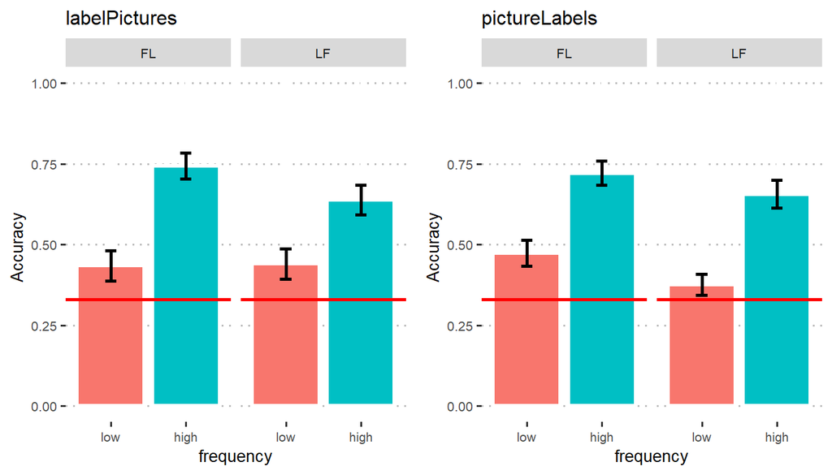

GLMMs models:

Picture label

```
##                          Estimate Std. Error  z value Pr(>|z|)
## (Intercept)               0.09817    0.21988  0.44649  0.65524
## frequencyhigh             1.64364    0.35383  4.64523  0.00000
## learningFL                0.55500    0.29760  1.86492  0.06219
## frequencyhigh:learningFL -0.18451    0.47891 -0.38527  0.70004
```

Label picture

```
##                          Estimate Std. Error z value Pr(>|z|)
## (Intercept)               0.22141    0.33964 0.65189  0.51447
## frequencyhigh             1.62196    0.49367 3.28552  0.00102
## learningFL                0.21452    0.46093 0.46540  0.64164
## frequencyhigh:learningFL  0.57714    0.67084 0.86033  0.38961
```

**What we have learned from these data:**

This means that the effect of frequency (high vs low) was super robust, and this is the only thing that we have replicated 100%. The difference between learnings unfortunately wasn’t there, although we see a trend in this direction in one task, but not the other. Why is this the case?

**How do we explain these results:** We don’t know for sure, however, throughout this experiment we have realised several important details that are not identical to the FLO paper and therefore could have affected the results:

- Learning: stimuli were pseudo-randomised with exemplars belonging to high and low frequency category of one category never displayed consequentially.
- The whole FLO experiment was visual, not audio, therefore this might cause less ambiguity, i.e., higher accuracy, and perfect balance in the test tasks for the trial duration. Also, this would remove the confound due to the addition of the sentence, in fact, we speculated that the two learnings varies in the contiguity between stimulus and label. I.e., FL: [fribble]+“This was a …. X” Versus LF: “This is a ….X”+[fribble] introduces two different types of lags between the presentation of the label and the stimulus. We speculated that this might cause differences, we don’t know how.
- Michael suggested that participants in his original experiment did only one of the two tasks, and not both. Exposition to both tasks might cause greater noise, especially in the labelPicture task where participants see 72 different fribbles. This might cause super confusion in the participants. Indeed, I found that from the folder Mike has shared with me (later on during this experiment) the number of stimuli didn’t match with the number of test trials reported in the paper.

**What we’re going to do next:** We’re goint to re-do the replication! This time for real: by checking for the right amount of test trials, same fribbles used by Michael and same modality.

```r
rm(adjusted.genTask_model, adjusted.labpic_model, adjusted.piclab_model, pl, pl_violin, lp, lp_violin, mystims, resp, saliency, FL_high_equilibriumsWeights, FL_low_equilibriumsWeights, freqBylearning_beta, frequency_beta, learning_beta, traceCues, traceOutcomes, LF_low_equilibriumsWeights, LF_high_equilibriumsWeights, conjudge_model, conjudge_model.emm, labpic_model, labpic_model.emm, LF_learningCurve, LF_asymptote, FL_learningCurve, FL_asymptote, summaryLP, summaryPL, respDistr)
```